# csmpv

Aixiang Jiang

2026-11-02

The csmpv R package provides an extensive set of functions that encompass biomarker confirmation, variable selection, modeling, predictive analysis, and validation. It can handle diverse outcome variable types, including binary, continuous, and time-to-event data. Its key objectives include:

- Biomarker Confirmation/Validation: This feature employs both single-variable and multivariable regression techniques to confirm and validate established biomarkers.
- Biomarker Discovery: The package streamlines the identification of new biomarkers through variable selection methods like LASSO2, LASSO_plus, and LASSO2plus.
- Predictive Model Development: By harnessing a fusion of machine learning and traditional statistical tools, this process facilitates the creation of predictive models focused on specific biomarkers.
- Model Prediction: Developed models can predict outcomes when applied to new datasets.
- Model Validation: These models validate outcomes when applied to novel datasets, provided an outcome variable is present.

To simplify the modeling process, we’ve designed an all-in-one function capable of managing predictive model development, prediction, and validation for all eight methods within this package across three distinct outcome types. This versatile function streamlines the process, allowing for a concise implementation with just a single function call. It can handle a single method with single or multiple outcome variables. Moreover, if a validation dataset is available, the prediction and validation processes can seamlessly integrate into a unified operation.

In addition to these core functionalities, the csmpv package introduces a unique approach allowing the creation of binary risk classification models based on survival models. This innovative feature enables predicting risk binary outcomes for new datasets using the developed model. Please note, the external validation of this model is limited due to the absence of binary classification variables in new datasets. Despite this limitation, the predicted binary classification can serve as a surrogate biomarker, and its correlation with survival outcomes in new datasets can be tested when survival outcome information is available.

To enhance user experience, the csmpv R package focuses on streamlining coding efforts. Each user-end function acts as a comprehensive wrapper condensing multiple analyses into a single function call. Additionally, result files are conveniently saved locally, further simplifying the analytical process.

# I Installation

The csmpv package is available on CRAN, and it can be directly installed in R using the following command:

```r
install.packages("csmpv")
```

Alternatively, let’s proceed to install csmpv from GitHub using the devtools or remotes R package.

```r
# Install devtools package if not already installed
options(repos = c(CRAN = "https://cloud.r-project.org"))
install.packages("devtools")

# Install csmpv package from GitHub
devtools::install_github("ajiangsfu/csmpv",force = TRUE)
# Using force = TRUE will ensure the installation, overriding any existing versions
```

```r
# Install remotes package if not already installed
install.packages("remotes")
# Install csmpv package from GitHub
remotes::install_github("ajiangsfu/csmpv",force = TRUE)
# Using force = TRUE will ensure the installation, overriding any existing versions
```

Both methods will download and install the csmpv package from the GitHub repository. Please ensure an active internet connection and the necessary dependencies for a successful installation.

# II Example Code

In this section, we will show some example code, however, before that, we will introduce example data first.

## 1. Example data

The example data was extracted from our in-house diffuse large B-cell lymphoma (DLBCL) dataset, specifically utilizing supplemental Table S1 from Alduaij et al. (2023, DOI: 10.1182/blood.2022018248).

To handle missing values, we retained only samples with all the necessary variables and no missing values. Furthermore, to ensure compatibility with all eight modeling methods within csmpv, we transformed all categorical variables into binary format, overcoming limitations in XGBoost (eXtreme Gradient Boosting) and LASSO (Least Absolute Shrinkage and Selection Operator) when dealing with categorical variables with more than two levels.

Following these procedures, an object named datlist was generated and is included in csmpv, accessible straightforwardly after installing and loading csmpv, as demonstrated below.

```r
library(csmpv)
data("datlist", package = "csmpv")
tdat = datlist$training
dim(tdat)
```

```
## [1] 216  22
```

```r
vdat = datlist$validation
dim(vdat)
```

```
## [1] 217  22
```

Subsequently, we defined three outcome variables and their respective independent variables.

To illustrate different types of outcome variables, we’ll define examples for binary, continuous, and time-to-event categories: - Binary: DZsig (dark zone signature) - Continuous: Age - Time-to-event: FFP (freedom from progression)

For the time-to-event outcome variable, independent variables are defined as:

```r
Xvars = c("B.Symptoms","MYC.IHC","BCL2.IHC", "CD10.IHC","BCL6.IHC",
 "MUM1.IHC","Male","AgeOver60", "stage3_4","PS1","LDH.Ratio1",
 "Extranodal1","Bulk10cm","HANS_GCB", "DTI")
```

For the continuous outcome variable, the corresponding independent variables align with those above, excluding AgeOver60 due to its correlation with the outcome variable Age:

```r
AgeXvars = setdiff(Xvars, "AgeOver60")
```

For the binary variable, the corresponding independent variables align with Xvars, excluding ‘HANS_GCB’ since DZsig classification is typically conducted within Germinal Center B-Cell (GCB) samples. In fact, no non-GCB sample is DZsig positive in our training dataset.

```r
DZXvars = setdiff(Xvars, "HANS_GCB")
```

To enhance reproducibility and minimize variability from random number generation, we established and set a specific random seed:

```r
set.seed(12345)
```

Users can define their own temporary directory to save all results. If not, tempdir() can be used to get the system’s temporary directory.

```r
temp_dir = tempdir()
knitr::opts_knit$set(root.dir = temp_dir)
```

## 2. Biomarker confirmation/validation

Whether this procedure is labeled as biomarker confirmation, validation, or testing, the fundamental aspect involves regular regression analyses on both single and multiple variables across three distinct outcome categories: binary, continuous, and time-to-event. In this context, our objective is to assess the presence of an association between outcomes and a set of independent variables. It’s important to note that this differs from model validation, which will be covered subsequently.

### 2.1 Binary outcome

To confirm biomarkers for binary outcomes:

```r
bconfirm = confirmVars(data = tdat, biomks = DZXvars, Y = "DZsig",
                       outfile = "confirmBinary")
```

The confirmVars function acts as a wrapper, invoking various functions to perform regression analysis based on different outcome types. By default, the outcome type is binary, requiring no explicit specification when handling binary outcomes.

Upon execution, the bconfirm object comprises a multivariable model and a list of two forest plots. The first plot consolidates individual forest plots for each single variable, while the second represents the forest plot for the multivariable model. These outputs are locally saved, along with a combined table containing models for each single variable.

```r
print(bconfirm$fit)
```

```
##
## Call:  glm(formula = f1, family = "binomial", data = datain)
##
## Coefficients:
## (Intercept)   B.Symptoms      MYC.IHC     BCL2.IHC     CD10.IHC     BCL6.IHC
##    -10.7121      -1.6743       3.6114       1.0875       4.5701       2.1497
##    MUM1.IHC         Male    AgeOver60     stage3_4          PS1   LDH.Ratio1
##     -3.0488       1.2451       0.2259       1.0134       2.4096       0.8555
## Extranodal1     Bulk10cm          DTI
##      0.9935      -1.0209      -0.0278
##
## Degrees of Freedom: 215 Total (i.e. Null);  201 Residual
## Null Deviance:       154.8
## Residual Deviance: 68.13     AIC: 98.13
```

```
## `height` was translated to `width`.
```

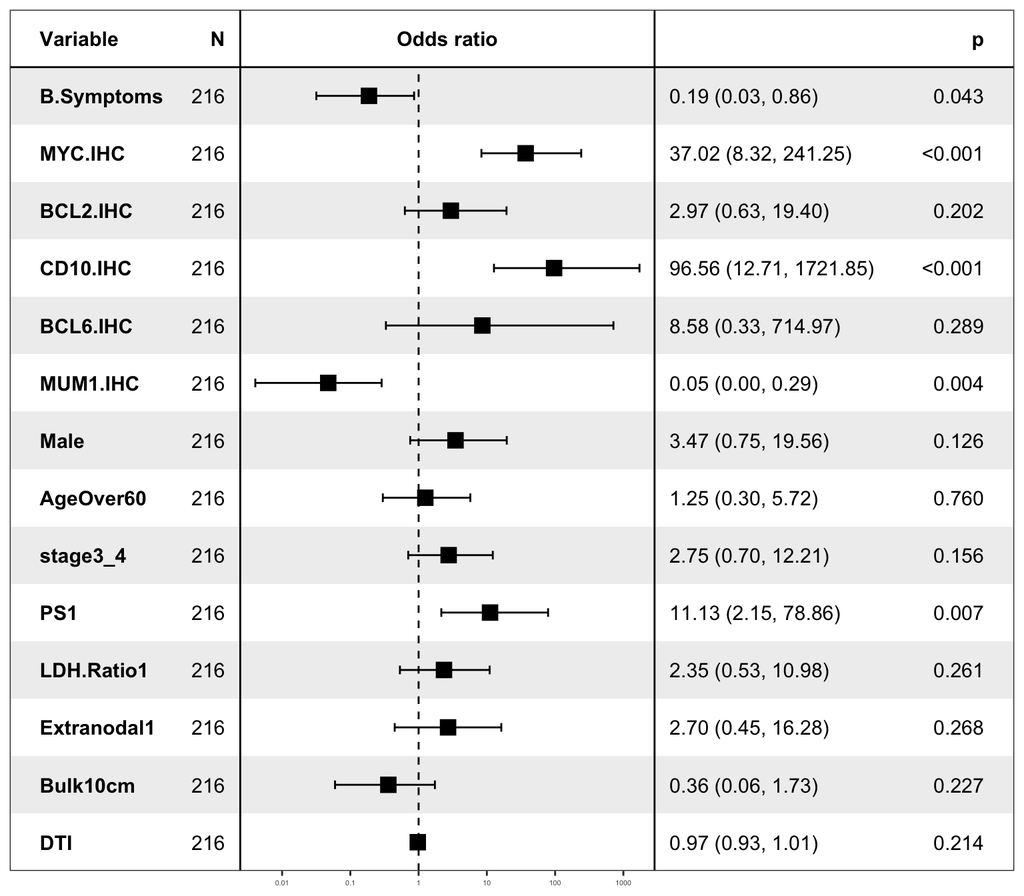

```r
bconfirm$allplot[[2]]
```

For instance, the above output showcases a multivariable model and it’s corresponding forest plot.

### 2.2 Continous outcome

To confirm biomarkers for continuous outcomes:

```r
cconfirm = confirmVars(data = tdat, biomks = AgeXvars, Y = "Age",
                       outcomeType = "continuous",
                       outfile = "confirmContinuous")
```

The same confirmVars function is called; however, this time, we specify the outcome type as continuous.

In a similar fashion, the cconfirm object comprises two elements: a multivariable model and a list of two forest plots. The first plot consolidates all forest plots for each single variable, while the second represents the forest plot for the multivariable model. All these outputs are saved locally, accompanied by a combined table containing models for each single variable.

Below, you’ll find the multivariable model and it’s corresponding forest plot:

```r
print(cconfirm$fit)
```

```
##
## Call:  glm(formula = f1, data = datain)
##
## Coefficients:
## (Intercept)   B.Symptoms      MYC.IHC     BCL2.IHC     CD10.IHC     BCL6.IHC
##    62.21516     -4.12244      1.76448      2.10272     -0.73413      1.65380
##    MUM1.IHC         Male     stage3_4          PS1   LDH.Ratio1  Extranodal1
##     1.47318     -1.47252     -1.24508      7.81629      2.41929     -4.91746
##    Bulk10cm     HANS_GCB          DTI
##    -1.91890      0.09254     -0.03078
##
## Degrees of Freedom: 215 Total (i.e. Null);  201 Residual
## Null Deviance:       41610
## Residual Deviance: 37060     AIC: 1756
```

```
## `height` was translated to `width`.
```

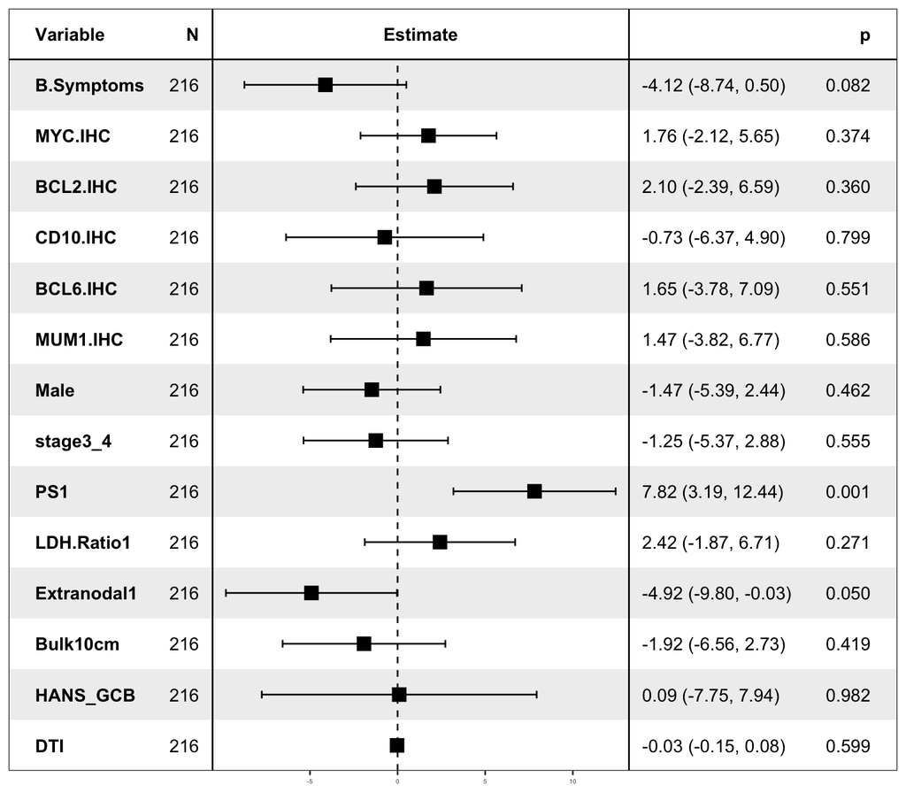

```r
cconfirm$allplot[[2]]
```

### 2.3 Time-to-event outcome

To confirm biomarkers for time-to-event outcomes:

```r
tconfirm = confirmVars(data = tdat, biomks = Xvars,
                       time = "FFP..Years.", event = "Code.FFP",
                       outcomeType = "time-to-event",
                       outfile = "confirmSurvival")
```

The confirmVars function is called once again, this time with the outcome type specified as time-to-event, necessitating the inclusion of both time and event variable names.

Similarly, two PDF and two table files are saved, accompanied by locally stored Kaplan-Meier plots. A single Kaplan-Meier plot is generated for each independent categorical variable with no more than four levels.

The tconfirm object also stores two elements: a multivariable model and a list of two forest plots. Below, you’ll find the multivariable model and it’s corresponding forest plot:

```r
print(tconfirm$fit)
```

```
## Call:
## survival::coxph(formula = as.formula(paste(survY, survX, sep = " ~ ")),
##     data = datain)
##
##                  coef exp(coef)  se(coef)      z        p
## B.Symptoms   0.242227  1.274083  0.254790  0.951  0.34176
## MYC.IHC      0.324999  1.384029  0.241800  1.344  0.17892
## BCL2.IHC     0.528284  1.696019  0.304773  1.733  0.08303
## CD10.IHC    -0.339371  0.712218  0.388523 -0.873  0.38240
## BCL6.IHC    -0.079421  0.923651  0.301262 -0.264  0.79207
## MUM1.IHC     0.265378  1.303924  0.323554  0.820  0.41210
## Male         0.509459  1.664390  0.239405  2.128  0.03334
## AgeOver60    0.275746  1.317513  0.268613  1.027  0.30463
## stage3_4     0.835319  2.305550  0.272658  3.064  0.00219
## PS1          0.615449  1.850486  0.251951  2.443  0.01458
## LDH.Ratio1   1.132954  3.104814  0.285240  3.972 7.13e-05
## Extranodal1  0.010644  1.010701  0.275702  0.039  0.96920
## Bulk10cm    -0.391782  0.675852  0.275208 -1.424  0.15457
## HANS_GCB     0.187281  1.205966  0.487752  0.384  0.70100
## DTI         -0.005751  0.994266  0.007605 -0.756  0.44953
##
## Likelihood ratio test=79.96  on 15 df, p=7.114e-11
## n= 216, number of events= 85
```

```
## `height` was translated to `width`.
```

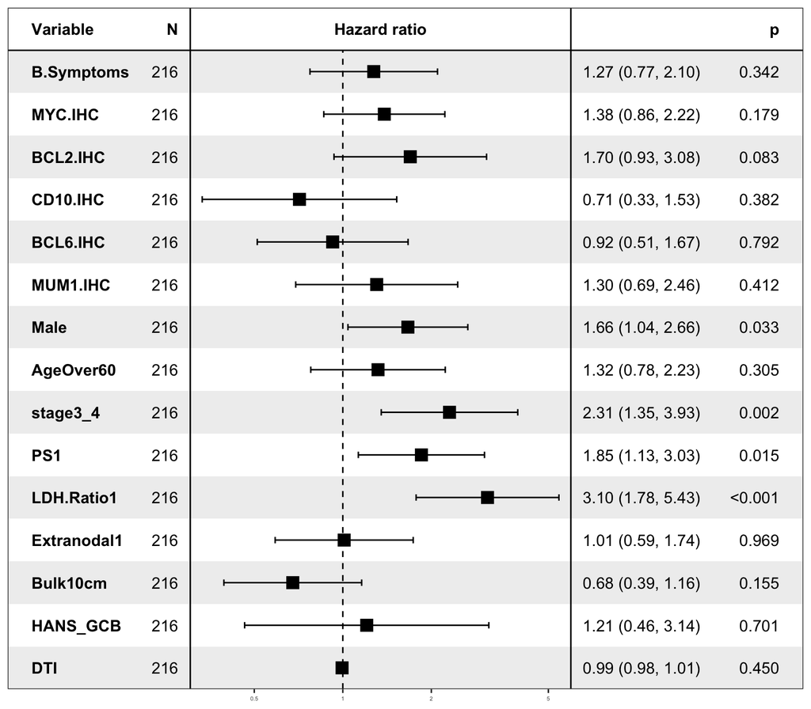

```r
tconfirm$allplot[[2]]
```

## 3. Biomarker discovery with variable selection

This section details the process of biomarker discovery through variable selection, utilizing three distinct methods: LASSO2, LASSO2plus, and LASSO_plus.

### 3.1 Variable selection with LASSO2

The variable selection process using our customized LASSO algorithm, LASSO2, employs a tailored approach distinct from the conventional LASSO algorithm. This adjustment aims to address the randomness introduced by random splits and to guarantee the inclusion of at least two variables.

This process utilizes glmnet::cv.glmnet for cross-validation-based variable selection, setting lambda as the largest value where the error remains within 1 standard error of the minimum. However, as indicated in the cv.glmnet’s help file, variability in results can arise due to the randomness inherent in cross-validation splits.

To counteract this variability, our new function, LASSO2, performs 10 runs of glmnet::cv.glmnet. The resulting average lambda value from these iterations becomes the final lambda used for regularization regression on the complete dataset.

It’s important to note that since LASSO2 selects the lambda as the largest lambda within 1 standard error of the minimum, following the default behavior of cv.glmnet, it may yield a smaller number of selected variables compared to the lambda that minimizes the mean cross-validated error. This more conservative approach could potentially result in only one or no selected variables.

To address this potential issue, when LASSO2 identifies only one or no variables, it defaults to selecting the first lambda that results in at least two variables being chosen from the full dataset. This strategy ensures the inclusion of at least two variables, striking a balance between model complexity and the necessity for meaningful variable inclusion.

#### 3.1.1 Binary outcome

For binary outcomes, no additional specification is needed for outcomeType, as it is the default value.

```r
bl = LASSO2(data = tdat, biomks = DZXvars, Y = "DZsig",
            outfile = "binaryLASSO2")
```

One figure and one text file are saved locally.

```r
bl$coefs
```

```
##    MYC.IHC   CD10.IHC   MUM1.IHC
##  0.9462028  1.5569619 -0.7759425
```

This displays the selected variables and their corresponding shrunken coefficients.

#### 3.1.2 Continuous outcome

For variable selection involving a continuous outcome variable, specify outcomeType = “continuous”:

```r
cl = LASSO2(data = tdat, biomks = AgeXvars,
            outcomeType = "continuous", Y = "Age",
            outfile = "continuousLASSO2")
```

Similar to before, one figure and one text file are saved locally.

```r
cl$coefs
```

```
##         PS1 Extranodal1
##  3.07601980 -0.01348528
```

This shows the selected variables and their associated shrunken coefficients for the continuous outcome.

#### 3.1.3 Time-to-event outcome

For variable selection with a time-to-event outcome, set outcomeType = “time-to-event”, and ensure you provide the variable names for both time and event:

```r
tl = LASSO2(data = tdat, biomks = Xvars,
            outcomeType = "time-to-event",
            time = "FFP..Years.",event = "Code.FFP",
            outfile = "survivalLASSO2")
```

In a similar fashion, one figure and one text file are saved locally.

```r
tl$coefs
```

```
##   stage3_4        PS1 LDH.Ratio1
## 0.05195271 0.05687925 0.46308447
```

This shows the selected variables and their associated shrunk coefficients for time-to-event outcome.

### 3.2 Variable selection with LASSO2plus

LASSO2plus is an innovative approach that combines LASSO2, a modified LASSO algorithm, with other techniques. It selects variables in three steps: - Apply LASSO2, which is slightly different from the standard LASSO as discussed in Section 3.1. - Fit a simple regression model for each variable and adjusting the p-values using the Benjamini Hochberg method (1995). - Perform a stepwise variable selection procedure on the combined list of variables from the previous steps. Therefore, LASSO2plus can incorporates both the regularization and the significance testing aspects of variable selection.

All parameter settings for LASSO2plus are the same as for LASSO2.

#### Binary outcome

For binary outcomes, no additional specification is needed for outcomeType, as it is the default value.

```r
b2fit = LASSO2plus(data = tdat, biomks = DZXvars, Y = "DZsig",
        outfile = "binaryLASSO2plus")
```

```
## Start:  AIC=101.72
## DZsig ~ MYC.IHC + CD10.IHC + MUM1.IHC
##
##            Df Deviance    AIC
## <none>           93.72 101.72
## - MUM1.IHC  1   107.09 113.09
## - MYC.IHC   1   115.41 121.41
## - CD10.IHC  1   119.33 125.33
```

```
## `height` was translated to `width`.
## file saved to binaryLASSO2plusLASSO2plus_varaibleSelection.pdf
```

```r
b2fit$fit$coefficients
```

```
## (Intercept)     MYC.IHC    CD10.IHC    MUM1.IHC
##   -4.778565    2.503030    3.188996   -2.553409
```

The coefficients are shown above. Two figures and two tables are stored locally.

#### Continuous outcome

For variable selection involving a continuous outcome variable, specify outcomeType = “continuous”:

```r
c2fit = LASSO2plus(data = tdat, biomks = AgeXvars,
                   outcomeType = "continuous", Y = "Age",
                   outfile = "continuousLASSO2plus")
```

```
## Start:  AIC=1742.74
## Age ~ PS1 + Extranodal1
##
##               Df Deviance    AIC
## <none>              38895 1742.7
## - Extranodal1  1    39626 1744.8
## - PS1          1    41202 1753.2
```

```
## `height` was translated to `width`.
## file saved to continuousLASSO2plusLASSO2plus_varaibleSelection.pdf
```

```r
c2fit$fit$coefficients
```

```
## (Intercept)         PS1 Extranodal1
##   63.266769    7.011195   -4.700672
```

Again, the coefficients shown above and Two figures and two tables are stored locally.

#### Time-to-event outcome

For variable selection with a time-to-event outcome, set outcomeType = “time-to-event”, and ensure you provide the variable names for both time and event:

```r
t2fit = LASSO2plus(data = tdat, biomks = Xvars,
                   outcomeType = "time-to-event",
                   time = "FFP..Years.",event = "Code.FFP",
                   outfile = "survivalLASSO2plus")
```

```
## Start:  AIC=813.41
## survival::Surv(FFP..Years., Code.FFP) ~ stage3_4 + PS1 + LDH.Ratio1 +
##     HANS_GCB + B.Symptoms + DTI + CD10.IHC + MUM1.IHC
##
##              Df    AIC
## - HANS_GCB    1 811.43
## - B.Symptoms  1 811.65
## - DTI         1 812.01
## - CD10.IHC    1 812.10
## - MUM1.IHC    1 812.37
## <none>          813.41
## - PS1         1 816.98
## - stage3_4    1 822.32
## - LDH.Ratio1  1 824.10
##
## Step:  AIC=811.43
## survival::Surv(FFP..Years., Code.FFP) ~ stage3_4 + PS1 + LDH.Ratio1 +
##     B.Symptoms + DTI + CD10.IHC + MUM1.IHC
##
##              Df    AIC
## - B.Symptoms  1 809.66
## - DTI         1 810.04
## - CD10.IHC    1 810.58
## - MUM1.IHC    1 810.62
## <none>          811.43
## - PS1         1 814.99
## - stage3_4    1 820.94
## - LDH.Ratio1  1 822.13
##
## Step:  AIC=809.66
## survival::Surv(FFP..Years., Code.FFP) ~ stage3_4 + PS1 + LDH.Ratio1 +
##     DTI + CD10.IHC + MUM1.IHC
##
##              Df    AIC
## - DTI         1 808.46
## - MUM1.IHC    1 808.86
## - CD10.IHC    1 808.94
## <none>          809.66
## - PS1         1 814.13
## - stage3_4    1 819.20
```

[output cut: 9 more lines]

```
## <none>          808.46
## - PS1         1 813.12
## - stage3_4    1 818.06
## - LDH.Ratio1  1 824.55
##
## Step:  AIC=807.66
## survival::Surv(FFP..Years., Code.FFP) ~ stage3_4 + PS1 + LDH.Ratio1 +
##     MUM1.IHC
##
##              Df    AIC
## <none>          807.66
## - MUM1.IHC    1 808.22
## - PS1         1 813.79
## - stage3_4    1 817.87
## - LDH.Ratio1  1 824.33
```

```
## `height` was translated to `width`.
## file saved to survivalLASSO2plusLASSO2plus_varaibleSelection.pdf
```

```r
t2fit$fit$coefficients
```

```
##   stage3_4        PS1 LDH.Ratio1   MUM1.IHC
##  0.8231937  0.6543237  1.0529572  0.3508003
```

Similar to the other types of outcomes, the coefficients are displayed above, and two figures along with two tables are stored locally.

### 3.3. Variable selection with LASSO_plus

LASSO_plus is another innovative approach that builds on the LASSO algorithm and adds more techniques. However, it differs from LASSO2plus that is described in Section 3.2 in its initial step. It selects variables in the following three steps:

- 1. Utilize ‘Modified LASSO’ for regularization regression instead of LASSO2 involves selecting a list, appearing at least two times during lambda simulations, based on the number of variables, and aiming to find the one nearest to a predefined target.
- 2. Fit a simple regression model for each variable and adjusting the p-values using the Benjamini Hochberg method (1995);
- 3. Perform a stepwise variable selection procedure on the combined list of variables from the previous steps. Therefore, LASSO_plus also incorporates both the regularization and the significance testing aspects of variable selection.

In LASSO_plus, all parameters from LASSO2 and LASSO2plus are retained, with the addition of the unique parameter topN. Please be aware that the topN parameter in LASSO_plus serves as a guide for variable selection.

#### Binary outcome

Setting the topN parameter to 5 is intended to incorporate the top 5 variables into the final model. However, it’s important to note that the resulting model may not always precisely comprise 5 variables. Consequently, when using the same topN value for different datasets, the number of selected variables may vary.

For binary outcomes, outcome type specification is unnecessary, as it defaults to this type.

```r
bfit = LASSO_plus(data = tdat, biomks = DZXvars, Y = "DZsig",
                  outfile = "binaryLASSO_plus", topN = 5)
```

```
## Start:  AIC=101.72
## DZsig ~ MYC.IHC + CD10.IHC + MUM1.IHC
##
##            Df Deviance    AIC
## <none>           93.72 101.72
## - MUM1.IHC  1   107.09 113.09
## - MYC.IHC   1   115.41 121.41
## - CD10.IHC  1   119.33 125.33
```

```
## `height` was translated to `width`.
## file saved to binaryLASSO_plus_LASSO_plus_varaibleSelection.pdf
```

```r
bfit$fit$coefficients
```

```
## (Intercept)     MYC.IHC    CD10.IHC    MUM1.IHC
##   -4.778565    2.503030    3.188996   -2.553409
```

The identified variables and their corresponding coefficients are displayed above. A figure and a table are locally stored.

#### Continuous outcome

For continuous outcome variables, ensure you specify outcomeType = “continuous”:

```r
cfit = LASSO_plus(data = tdat, biomks = AgeXvars,
                  outcomeType = "continuous", Y = "Age",
                  outfile = "continuousLASSO_plus", topN = 5)
```

```
## Start:  AIC=1745.43
## Age ~ MUM1.IHC + Male + PS1 + LDH.Ratio1 + Extranodal1
##
##               Df Deviance    AIC
## - LDH.Ratio1   1    38409 1744.0
## - Male         1    38469 1744.4
## - MUM1.IHC     1    38527 1744.7
## <none>              38303 1745.4
## - Extranodal1  1    39063 1747.7
## - PS1          1    39749 1751.4
##
## Step:  AIC=1744.03
## Age ~ MUM1.IHC + Male + PS1 + Extranodal1
##
##               Df Deviance    AIC
## - Male         1    38610 1743.2
## - MUM1.IHC     1    38640 1743.3
## <none>              38409 1744.0
## - Extranodal1  1    39174 1746.3
## - PS1          1    40373 1752.8
##
## Step:  AIC=1743.15
## Age ~ MUM1.IHC + PS1 + Extranodal1
##
##               Df Deviance    AIC
## - MUM1.IHC     1    38895 1742.7
## <none>              38610 1743.2
## - Extranodal1  1    39383 1745.4
## - PS1          1    40715 1752.6
##
## Step:  AIC=1742.74
## Age ~ PS1 + Extranodal1
##
##               Df Deviance    AIC
## <none>              38895 1742.7
## - Extranodal1  1    39626 1744.8
## - PS1          1    41202 1753.2
```

```
## `height` was translated to `width`.
## file saved to continuousLASSO_plus_LASSO_plus_varaibleSelection.pdf
```

```r
cfit$fit$coefficients
```

```
## (Intercept)         PS1 Extranodal1
##   63.266769    7.011195   -4.700672
```

The identified variables and their corresponding coefficients are displayed above. A figure and a table are locally stored

#### Time-to-event outcome

When dealing with time-to-event outcomes, set outcomeType = “time-to-event”, and ensure you provide the names of variables for both time and event:

```r
tfit = LASSO_plus(data = tdat, biomks = Xvars,
                  outcomeType = "time-to-event",
                  time = "FFP..Years.",event = "Code.FFP",
                  outfile = "survivalLASSO_plus", topN = 5)
```

```
## Start:  AIC=811.93
## survival::Surv(FFP..Years., Code.FFP) ~ BCL2.IHC + stage3_4 +
##     PS1 + LDH.Ratio1 + HANS_GCB + B.Symptoms + DTI + CD10.IHC +
##     MUM1.IHC
##
##              Df    AIC
## - HANS_GCB    1 810.06
## - DTI         1 810.26
## - B.Symptoms  1 810.44
## - MUM1.IHC    1 810.61
## - CD10.IHC    1 811.03
## <none>          811.93
## - BCL2.IHC    1 813.41
## - PS1         1 815.39
## - stage3_4    1 820.54
## - LDH.Ratio1  1 824.07
##
## Step:  AIC=810.06
## survival::Surv(FFP..Years., Code.FFP) ~ BCL2.IHC + stage3_4 +
##     PS1 + LDH.Ratio1 + B.Symptoms + DTI + CD10.IHC + MUM1.IHC
##
##              Df    AIC
## - DTI         1 808.41
## - B.Symptoms  1 808.53
## - MUM1.IHC    1 808.62
## - CD10.IHC    1 809.45
## <none>          810.06
## - BCL2.IHC    1 811.43
## - PS1         1 813.41
## - stage3_4    1 818.84
## - LDH.Ratio1  1 822.17
##
## Step:  AIC=808.41
## survival::Surv(FFP..Years., Code.FFP) ~ BCL2.IHC + stage3_4 +
##     PS1 + LDH.Ratio1 + B.Symptoms + CD10.IHC + MUM1.IHC
##
##              Df    AIC
## - MUM1.IHC    1 806.98
## - B.Symptoms  1 807.07
## - CD10.IHC    1 807.77
```

[output cut: 15 more lines]

```
## - PS1         1 810.11
## - stage3_4    1 815.89
## - LDH.Ratio1  1 823.62
##
## Step:  AIC=805.67
## survival::Surv(FFP..Years., Code.FFP) ~ BCL2.IHC + stage3_4 +
##     PS1 + LDH.Ratio1 + CD10.IHC
##
##              Df    AIC
## <none>          805.67
## - CD10.IHC    1 806.28
## - BCL2.IHC    1 807.79
## - PS1         1 810.33
## - stage3_4    1 814.88
## - LDH.Ratio1  1 823.04
```

```
## `height` was translated to `width`.
## file saved to survivalLASSO_plus_LASSO_plus_varaibleSelection.pdf
```

```r
tfit$fit$coefficients
```

```
##   BCL2.IHC   stage3_4        PS1 LDH.Ratio1   CD10.IHC
##  0.5624989  0.7912045  0.6026647  1.0807901 -0.3868876
```

Displayed above are the identified variables and their corresponding coefficients. A figure and a table are locally stored

## 4. Predictive model development

Predictive model development is a crucial aspect of the csmpv R package, involving eight distinct approaches:

- Use shrunk coefficients directly from LASSO2.
- Select variables with LASSO2, then run a regular regression model.
- Extract coefficients directly from LASSO_plus output.
- Extract coefficients directly from LASSO2plus output.
- Build a machine learning model with XGBoost.
- Utilize LASSO2 for variable selection and build an XGBoost model.
- Utilize LASSO_plus for variable selection and build an XGBoost model.
- Utilize LASSO2plus for variable selection and build an XGBoost model.

### 4.1 LASSO2

Directly use shrunk coefficients from LASSO2 output as shown in Section 3.1.

### 4.2 LASSO2 + regular regression

The approach involves utilizing the variables selected by LASSO2 to conduct a standard regression model. Rather than relying on the shrunken coefficients obtained from LASSO2, this method opts for a conventional regression analysis with the chosen variables.

While it’s feasible to manually extract variables from an LASSO2 object for regular regression based on the outcome type, LASSO2_reg function is introduced to simplify this process for coding convenience and efficiency.

All parameter settings are the same as for LASSO2.

#### Binary outcome

```r
blr = LASSO2_reg(data = tdat, biomks = DZXvars, Y = "DZsig",
                 outfile = "binaryLASSO2_reg")
```

```r
blr$fit$coefficients
```

```
## (Intercept)     MYC.IHC    CD10.IHC    MUM1.IHC
##   -4.778565    2.503030    3.188996   -2.553409
```

#### Continuous outcome

```r
clr = LASSO2_reg(data = tdat, biomks = AgeXvars,
                 outcomeType = "continuous", Y = "Age",
                 outfile = "continuousLASSO2_reg")
```

```r
clr$fit$coefficients
```

```
## (Intercept)         PS1 Extranodal1
##   63.266769    7.011195   -4.700672
```

#### Time-to-event outcome

```r
tlr = LASSO2_reg(data = tdat, biomks = Xvars,
                 outcomeType = "time-to-event",
                 time = "FFP..Years.",event = "Code.FFP",
                 outfile = "survivalLASSO2_reg")
```

```r
tlr$fit$coefficients
```

```
##   stage3_4        PS1 LDH.Ratio1
##  0.8406613  0.6921943  1.0459259
```

The selected variables and their coefficients are displayed above. For each outcome type, three figure files, one text file, and two tables are saved locally. Furthermore, Kaplan-Meier plots are generated and saved locally for time-to-event outcome variables. Specifically, a single Kaplan-Meier plot is produced for each independent categorical variable, with no more than four levels.

### 4.4 LASSO2plus

Directly use coefficients from the LASSO2plus output, as described in Section 3.2.

### 4.5 XGBoost

XGBoost is a powerful machine learning algorithm recognized for its boosting capabilities. The XGBtraining function within the csmpv package leverages the strengths of XGBoost for model training. As XGBoost doesn’t inherently feature a dedicated variable selection procedure, you’ll need to manually define or select a set of variables using other methods. Once you have a predefined set of variables for constructing an XGBoost model, the XGBtraining function in the csmpv package streamlines this process.

#### Binary outcome

```r
bxfit = XGBtraining(data = tdat, biomks = DZXvars, Y = "DZsig",
                    outfile = "binary_XGBoost")
head(bxfit$XGBoost_score)
```

```
##      pt103      pt246      pt874      pt219      pt138      pt328
## 0.11767066 0.03590937 0.64021587 0.03692833 0.10257415 0.08567930
```

The bxfit object contains four components:

- XGBoost object.
- XGBoost scores for all entries in the tdat dataset. Notably, XGBoost operates as a black box model and doesn’t return coefficients; however, it provides model scores. For binary outcomes, these scores represent the probability of the positive class.
- Observed outcome.
- Outcome type.

#### Continuous outcome

```r
cxfit = XGBtraining(data = tdat, biomks = AgeXvars,
                    outcomeType = "continuous", Y = "Age",
                    outfile = "continuous_XGBoost")
head(cxfit$XGBoost_score)
```

```
##    pt103    pt246    pt874    pt219    pt138    pt328
## 66.27252 63.29570 63.18344 65.77276 60.32026 63.33891
```

Within cxfit, there are four elements:

- XGBoost object.
- XGBoost scores for all entries in tdat. Notably, XGBoost, functioning as a black box model, does not yield coefficients but provides model scores. For continuous outcomes, these scores represent the estimated continuous values.
- Observed outcome.
- Outcome type.

#### Time-to-event outcome

```r
txfit = XGBtraining(data = tdat, biomks = Xvars,
                    outcomeType = "time-to-event",
                    time = "FFP..Years.",event = "Code.FFP",
                    outfile = "survival_XGBoost")
head(txfit$XGBoost_score)
```

```
##     pt103     pt246     pt874     pt219     pt138     pt328
## 2.3212001 0.5570496 3.7005746 0.7991223 0.3685817 0.8035265
```

In txfit, there are six components:

- XGBoost object.
- XGBoost scores for all entries in tdat. Notably, XGBoost operates as a black box model and does not yield coefficients but provides model scores. For time-to-event outcomes, these scores represent the risk score.
- Baseline hazard table.
- Observed time.
- Event.
- Outcome type.

### 4.6 LASSO2 + XGBoost

Combine LASSO2 variable selection with XGBoost modeling using the LASSO2_XGBtraining function, which selects variables via LASSO2 but constructs an XGBoost model without relying on shrunk coefficients. The resulting objects maintain the same format as XGBtraining, while the results related to LASSO2 and XGBoost are saved locally.

#### Binary outcome

```r
blxfit = LASSO2_XGBtraining(data = tdat, biomks = DZXvars, Y = "DZsig",
                            outfile = "binary_LASSO2_XGBoost")
head(blxfit$XGBoost_score)
```

```
##      pt103      pt246      pt874      pt219      pt138      pt328
## 0.06075158 0.04866171 0.56193715 0.03976288 0.14205624 0.06075158
```

#### Continuous outcome

```r
clxfit = LASSO2_XGBtraining(data = tdat, biomks = AgeXvars,
                            outcomeType = "continuous", Y = "Age",
                            outfile = "continuous_LASSO2_XGBoost")
head(clxfit$XGBoost_score)
```

```
##    pt103    pt246    pt874    pt219    pt138    pt328
## 65.26795 63.48604 65.26795 63.48604 63.48604 63.48604
```

#### Time-to-event outcome

```r
tlxfit = LASSO2_XGBtraining(data = tdat, biomks = Xvars,
                            outcomeType = "time-to-event",
                            time = "FFP..Years.",event = "Code.FFP",
                            outfile = "survival_LASSO2_XGBoost")
head(tlxfit$XGBoost_score)
```

```
##     pt103     pt246     pt874     pt219     pt138     pt328
## 2.9907691 0.6261021 2.9907691 0.6261021 0.4448999 1.5880196
```

### 4.7 LASSO_plus + XGBoost

To combine LASSO_plus variable selection with XGBoost modeling, the LASSO_plus_XGBtraining R function is employed. This approach selects variables using LASSO_plus but does not utilize the coefficients from LASSO_plus to construct the model; instead, it generates an XGBoost model.

The format of the returned objects are identical to those of the XGBtraining function, while results related to LASSO_plus and XGBoost are saved locally.

#### Binary outcome

```r
blpxfit = LASSO_plus_XGBtraining(data = tdat, biomks = DZXvars, Y = "DZsig",
                                 topN = 5,outfile = "binary_LASSO_plus_XGBoost")
```

```
## Start:  AIC=101.72
## DZsig ~ MYC.IHC + CD10.IHC + MUM1.IHC
##
##            Df Deviance    AIC
## <none>           93.72 101.72
## - MUM1.IHC  1   107.09 113.09
## - MYC.IHC   1   115.41 121.41
## - CD10.IHC  1   119.33 125.33
```

```
## `height` was translated to `width`.
## file saved to binary_LASSO_plus_XGBoost_LASSO_plus_varaibleSelection.pdf
```

```r
head(blpxfit$XGBoost_score)
```

```
##      pt103      pt246      pt874      pt219      pt138      pt328
## 0.06075158 0.04866171 0.56193715 0.03976288 0.14205624 0.06075158
```

The majority of the outputs stem from LASSO_plus, with the final portion being attributed to XGBoost.

#### Continuous outcome

```r
clpxfit = LASSO_plus_XGBtraining(data = tdat, biomks = AgeXvars,
                                 outcomeType = "continuous", Y = "Age",
                                 topN = 5,outfile = "continuous_LASSO_plus_XGBoost")
```

```
## Start:  AIC=1745.43
## Age ~ MUM1.IHC + Male + PS1 + LDH.Ratio1 + Extranodal1
##
##               Df Deviance    AIC
## - LDH.Ratio1   1    38409 1744.0
## - Male         1    38469 1744.4
## - MUM1.IHC     1    38527 1744.7
## <none>              38303 1745.4
## - Extranodal1  1    39063 1747.7
## - PS1          1    39749 1751.4
##
## Step:  AIC=1744.03
## Age ~ MUM1.IHC + Male + PS1 + Extranodal1
##
##               Df Deviance    AIC
## - Male         1    38610 1743.2
## - MUM1.IHC     1    38640 1743.3
## <none>              38409 1744.0
## - Extranodal1  1    39174 1746.3
## - PS1          1    40373 1752.8
##
## Step:  AIC=1743.15
## Age ~ MUM1.IHC + PS1 + Extranodal1
##
##               Df Deviance    AIC
## - MUM1.IHC     1    38895 1742.7
## <none>              38610 1743.2
## - Extranodal1  1    39383 1745.4
## - PS1          1    40715 1752.6
##
## Step:  AIC=1742.74
## Age ~ PS1 + Extranodal1
##
##               Df Deviance    AIC
## <none>              38895 1742.7
## - Extranodal1  1    39626 1744.8
## - PS1          1    41202 1753.2
```

```
## `height` was translated to `width`.
## file saved to continuous_LASSO_plus_XGBoost_LASSO_plus_varaibleSelection.pdf
```

```r
head(clpxfit$XGBoost_score)
```

```
##    pt103    pt246    pt874    pt219    pt138    pt328
## 65.26795 63.48604 65.26795 63.48604 63.48604 63.48604
```

Similar to the previous scenario, the primary outputs stem from LASSO_plus, while the concluding section originates from XGBoost.

#### Time-to-event outcome

```r
tlpxfit = LASSO_plus_XGBtraining(data = tdat, biomks = Xvars,
                                 outcomeType = "time-to-event",
                                 time = "FFP..Years.",event = "Code.FFP",
                                 topN = 5,outfile = "survival_LASSO_plus_XGBoost")
```

```
## Start:  AIC=811.93
## survival::Surv(FFP..Years., Code.FFP) ~ BCL2.IHC + stage3_4 +
##     PS1 + LDH.Ratio1 + HANS_GCB + B.Symptoms + DTI + CD10.IHC +
##     MUM1.IHC
##
##              Df    AIC
## - HANS_GCB    1 810.06
## - DTI         1 810.26
## - B.Symptoms  1 810.44
## - MUM1.IHC    1 810.61
## - CD10.IHC    1 811.03
## <none>          811.93
## - BCL2.IHC    1 813.41
## - PS1         1 815.39
## - stage3_4    1 820.54
## - LDH.Ratio1  1 824.07
##
## Step:  AIC=810.06
## survival::Surv(FFP..Years., Code.FFP) ~ BCL2.IHC + stage3_4 +
##     PS1 + LDH.Ratio1 + B.Symptoms + DTI + CD10.IHC + MUM1.IHC
##
##              Df    AIC
## - DTI         1 808.41
## - B.Symptoms  1 808.53
## - MUM1.IHC    1 808.62
## - CD10.IHC    1 809.45
## <none>          810.06
## - BCL2.IHC    1 811.43
## - PS1         1 813.41
## - stage3_4    1 818.84
## - LDH.Ratio1  1 822.17
##
## Step:  AIC=808.41
## survival::Surv(FFP..Years., Code.FFP) ~ BCL2.IHC + stage3_4 +
##     PS1 + LDH.Ratio1 + B.Symptoms + CD10.IHC + MUM1.IHC
##
##              Df    AIC
## - MUM1.IHC    1 806.98
## - B.Symptoms  1 807.07
## - CD10.IHC    1 807.77
```

[output cut: 15 more lines]

```
## - PS1         1 810.11
## - stage3_4    1 815.89
## - LDH.Ratio1  1 823.62
##
## Step:  AIC=805.67
## survival::Surv(FFP..Years., Code.FFP) ~ BCL2.IHC + stage3_4 +
##     PS1 + LDH.Ratio1 + CD10.IHC
##
##              Df    AIC
## <none>          805.67
## - CD10.IHC    1 806.28
## - BCL2.IHC    1 807.79
## - PS1         1 810.33
## - stage3_4    1 814.88
## - LDH.Ratio1  1 823.04
```

```
## `height` was translated to `width`.
## file saved to survival_LASSO_plus_XGBoost_LASSO_plus_varaibleSelection.pdf
```

```r
head(tlpxfit$XGBoost_score)
```

```
##     pt103     pt246     pt874     pt219     pt138     pt328
## 3.1900742 0.8477585 3.1900742 0.8477585 0.3921926 1.5725721
```

Analogous to the previous cases, the bulk of the outputs originate from LASSO_plus, while the final segment is attributed to XGBoost.

### 4.8 LASSO2plus + XGBoost

To seamlessly integrate LASSO2plus variable selection with XGBoost modeling, we leverage the LASSO2plus_XGBtraining R function. This hybrid approach utilizes LASSO2plus for variable selection but diverges from using its coefficients to construct the model. Instead, it generates an XGBoost model, producing an output akin to that of the XGBtraining function.

The format of the returned objects mirror those of the XGBtraining function, while results related to LASSO2plus and XGBoost are saved locally.

#### Binary outcome

```r
bl2xfit = LASSO2plus_XGBtraining(data = tdat, biomks = DZXvars, Y = "DZsig",
                                 outfile = "binary_LASSO2plus_XGBoost")
```

```
## Start:  AIC=101.72
## DZsig ~ MYC.IHC + CD10.IHC + MUM1.IHC
##
##            Df Deviance    AIC
## <none>           93.72 101.72
## - MUM1.IHC  1   107.09 113.09
## - MYC.IHC   1   115.41 121.41
## - CD10.IHC  1   119.33 125.33
```

```
## `height` was translated to `width`.
## file saved to binary_LASSO2plus_XGBoostLASSO2plus_varaibleSelection.pdf
```

```r
head(bl2xfit$XGBoost_score)
```

```
##      pt103      pt246      pt874      pt219      pt138      pt328
## 0.06075158 0.04866171 0.56193715 0.03976288 0.14205624 0.06075158
```

The primary outputs stem from LASSO2plus, while the latter part pertains to XGBoost.

#### Continuous outcome

```r
cl2xfit = LASSO2plus_XGBtraining(data = tdat, biomks = AgeXvars,
                                 outcomeType = "continuous", Y = "Age",
                                 outfile = "continuous_LASSO2plus_XGBoost")
```

```
## Start:  AIC=1742.74
## Age ~ PS1 + Extranodal1
##
##               Df Deviance    AIC
## <none>              38895 1742.7
## - Extranodal1  1    39626 1744.8
## - PS1          1    41202 1753.2
```

```
## `height` was translated to `width`.
## file saved to continuous_LASSO2plus_XGBoostLASSO2plus_varaibleSelection.pdf
```

```r
head(cl2xfit$XGBoost_score)
```

```
##    pt103    pt246    pt874    pt219    pt138    pt328
## 65.26795 63.48604 65.26795 63.48604 63.48604 63.48604
```

Similar to the previous case, the primary outputs arise from LASSO2plus, while the final section pertains to XGBoost.

#### Time-to-event outcome

```r
tl2xfit = LASSO2plus_XGBtraining(data = tdat, biomks = Xvars,
                                 outcomeType = "time-to-event",
                                 time = "FFP..Years.", event = "Code.FFP",
                                 outfile = "survival_LASSO2plus_XGBoost")
```

```
## Start:  AIC=813.41
## survival::Surv(FFP..Years., Code.FFP) ~ stage3_4 + PS1 + LDH.Ratio1 +
##     HANS_GCB + B.Symptoms + DTI + CD10.IHC + MUM1.IHC
##
##              Df    AIC
## - HANS_GCB    1 811.43
## - B.Symptoms  1 811.65
## - DTI         1 812.01
## - CD10.IHC    1 812.10
## - MUM1.IHC    1 812.37
## <none>          813.41
## - PS1         1 816.98
## - stage3_4    1 822.32
## - LDH.Ratio1  1 824.10
##
## Step:  AIC=811.43
## survival::Surv(FFP..Years., Code.FFP) ~ stage3_4 + PS1 + LDH.Ratio1 +
##     B.Symptoms + DTI + CD10.IHC + MUM1.IHC
##
##              Df    AIC
## - B.Symptoms  1 809.66
## - DTI         1 810.04
## - CD10.IHC    1 810.58
## - MUM1.IHC    1 810.62
## <none>          811.43
## - PS1         1 814.99
## - stage3_4    1 820.94
## - LDH.Ratio1  1 822.13
##
## Step:  AIC=809.66
## survival::Surv(FFP..Years., Code.FFP) ~ stage3_4 + PS1 + LDH.Ratio1 +
##     DTI + CD10.IHC + MUM1.IHC
##
##              Df    AIC
## - DTI         1 808.46
## - MUM1.IHC    1 808.86
## - CD10.IHC    1 808.94
## <none>          809.66
## - PS1         1 814.13
## - stage3_4    1 819.20
```

[output cut: 9 more lines]

```
## <none>          808.46
## - PS1         1 813.12
## - stage3_4    1 818.06
## - LDH.Ratio1  1 824.55
##
## Step:  AIC=807.66
## survival::Surv(FFP..Years., Code.FFP) ~ stage3_4 + PS1 + LDH.Ratio1 +
##     MUM1.IHC
##
##              Df    AIC
## <none>          807.66
## - MUM1.IHC    1 808.22
## - PS1         1 813.79
## - stage3_4    1 817.87
## - LDH.Ratio1  1 824.33
```

```
## `height` was translated to `width`.
## file saved to survival_LASSO2plus_XGBoostLASSO2plus_varaibleSelection.pdf
```

```r
head(tl2xfit$XGBoost_score)
```

```
##     pt103     pt246     pt874     pt219     pt138     pt328
## 3.0028634 0.5686219 3.0028634 0.7364585 0.3530435 1.5939485
```

Similarly, most outputs arise from LASSO2plus, while the final section pertains to XGBoost.

## 5. Model prediction

### 5.1 LASSO2 prediction

We begin by discussing predictions for LASSO2 model outcomes.

#### Binary ouctome

To predict binary outcomes using LASSO2, we use the following code snippet:

```r
pbl = LASSO2_predict(bl, newdata = vdat, outfile = "pred_LASSO2_binary")
head(pbl)
```

```
##        pt3       pt10       pt20       pt25       pt30       pt52
## 0.21081585 0.18388045 0.04533691 0.04533691 0.10899635 0.02139063
```

The pbl object holds the predicted probabilities for the positive group for each entry/sample.

#### Continuous ouctome

For continuous outcomes prediction, the code snippet is as follows:

```r
pcl = LASSO2_predict(cl, newdata = vdat, outfile = "pred_LASSO2_cont")
head(pbl)
```

```
##        pt3       pt10       pt20       pt25       pt30       pt52
## 0.21081585 0.18388045 0.04533691 0.04533691 0.10899635 0.02139063
```

The pcl object holds the predicted Y values for each entry/sample.

#### Time-to-event ouctome

When predicting time-to-event outcomes, we use the code:

```r
ptl = LASSO2_predict(tl, newdata = vdat,
                     outfile = "pred_LASSO2_time_to_event")
head(pbl)
```

```
##        pt3       pt10       pt20       pt25       pt30       pt52
## 0.21081585 0.18388045 0.04533691 0.04533691 0.10899635 0.02139063
```

The ptl object holds predicted risk scores for each entry/sample.

### 5.2 LASSO2 + regular regression prediction

Moving forward, let’s explore predictions regarding the regression model using selected variables from LASSO2. The function rms_model specifically caters to model prediction when utilizing a regular modeling object like those produced by LASSO2_reg. Upon performing predictions for binary and continuous outcomes, this step generates one figure and five tables. Additionally, for time-to-event outcomes, an extra table is generated. These resulting files are all saved locally for convenient access.

#### Binary ouctome

To predict binary outcomes using the LASSO2 + regular regression model:

```r
pblr = rms_model(blr$fit, newdata = vdat, outfile = "pred_LASSO2reg_binary")
```

```
##             index.orig     training        test     optimism index.corrected
## Dxy        0.790157068  0.805958224  0.77772984  0.028228381      0.76192869
## R2         0.481472357  0.502046578  0.44056154  0.061485039      0.41998732
## Intercept  0.000000000  0.000000000 -0.17251617  0.172516175     -0.17251617
## Slope      1.000000000  1.000000000  0.81060543  0.189394572      0.81060543
## Emax       0.000000000  0.000000000  0.07875158  0.078751577      0.07875158
## D          0.278185437  0.287909840  0.25150683  0.036403006      0.24178243
## U         -0.009259259 -0.009259259  0.03208672 -0.041345976      0.03208672
## Q          0.287444696  0.297169099  0.21942012  0.077748982      0.20969571
## B          0.064166124  0.060452546  0.06639148 -0.005938932      0.07010506
## g          2.702828922  4.275410831  2.70154156  1.573869266      1.12895966
## gp         0.162611026  0.161069642  0.15704622  0.004023421      0.15858761
## Cindex     0.895078534  0.902979112  0.88886492  0.014114190      0.88096434
##             n
## Dxy       200
## R2        200
## Intercept 200
## Slope     200
## Emax      200
## D         200
## U         200
## Q         200
## B         200
## g         200
## gp        200
## Cindex    200
```

```r
head(pblr)
```

```
##       pt3      pt10      pt20      pt25      pt30      pt52
## -1.639948 -1.589569 -4.778565 -4.778565 -2.275535 -7.331975
```

#### Continuous ouctome

For continuous outcomes prediction:

```r
pclr = rms_model(clr$fit, newdata = vdat,
                 outfile = "pred_LASSO2reg_continuous")
```

```
##           index.orig training     test optimism index.corrected   n
## R-square      0.0652   0.0730   0.0522   0.0207          0.0444 200
## MSE         180.0675 174.7211 182.5601  -7.8390        187.9065 200
## g             3.6221   3.6438   3.4452   0.1986          3.4235 200
## Intercept     0.0000   0.0000  -0.3951   0.3951         -0.3951 200
## Slope         1.0000   1.0000   1.0044  -0.0044          1.0044 200
```

```r
head(pclr)
```

```
##      pt3     pt10     pt20     pt25     pt30     pt52
## 63.26677 63.26677 63.26677 65.57729 63.26677 58.56610
```

#### Time-to-event ouctome

To predict time-to-event outcomes:

```r
ptlr = rms_model(tlr$fit, data = tdat, newdata = vdat,
                outfile = "pred_LASSO2reg_time_to_event")
```

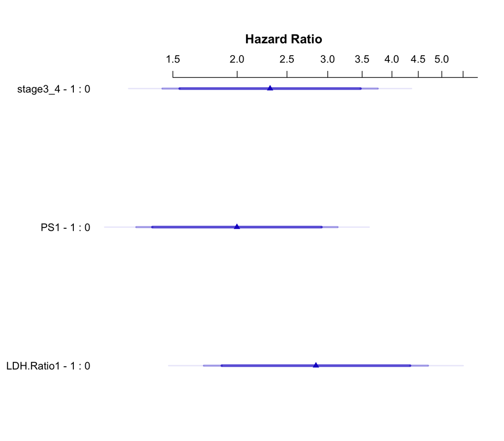

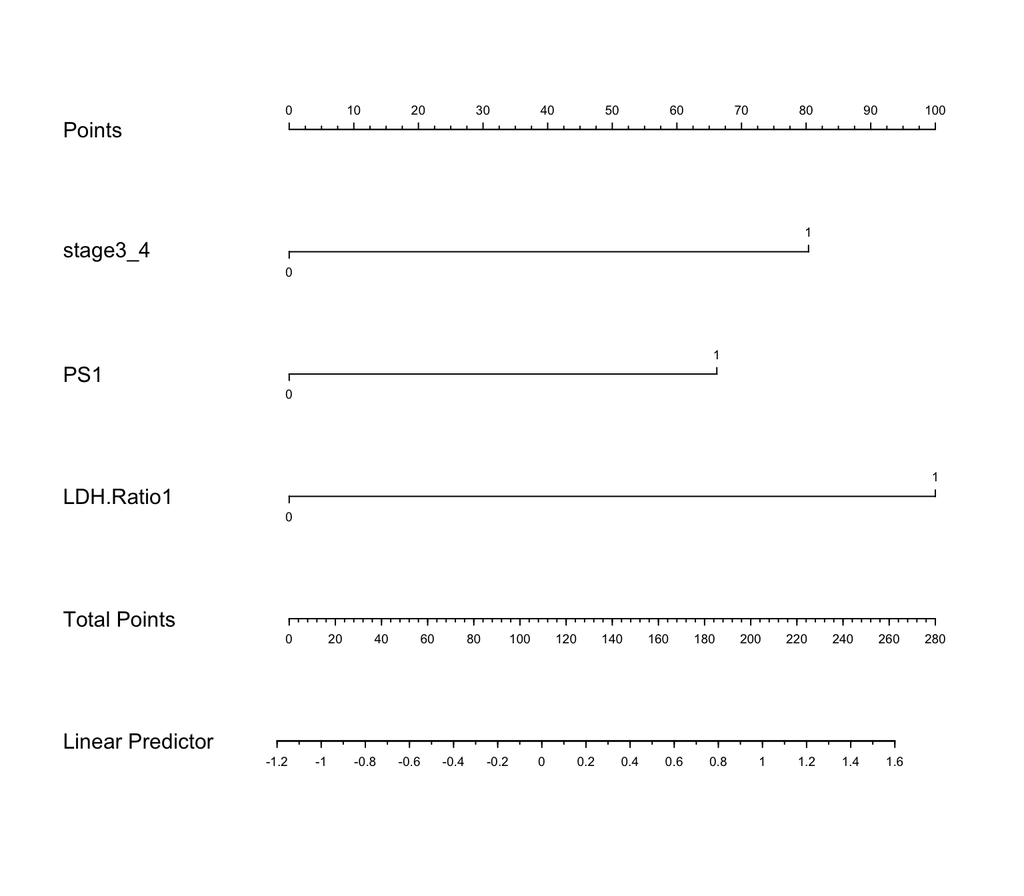

```
##          index.orig     training        test     optimism index.corrected   n
## Dxy     0.497655584  0.501822784 0.486611253  0.015211531     0.482444053 200
## R2      0.256358679  0.270053554 0.249870668  0.020182886     0.236175793 200
## Slope   1.000000000  1.000000000 0.956092271  0.043907729     0.956092271 200
## D       0.071254401  0.076254098 0.069147551  0.007106547     0.064147854 200
## U      -0.002312546 -0.002320255 0.001323316 -0.003643571     0.001331025 200
## Q       0.073566947  0.078574353 0.067824235  0.010750118     0.062816829 200
## g       1.041611086  1.081088585 1.023062661  0.058025924     0.983585163 200
## Cindex  0.748827792  0.750911392 0.743305627  0.007605765     0.741222027 200
```

```r
head(ptlr)
```

```
##        pt3       pt10       pt20       pt25       pt30       pt52
##  0.7415249  0.7415249 -1.1450622  0.3877932  0.7415249  0.7415249
```

For time-to-event outcomes, the LASSO2_reg object requires the training dataset to be provided.

### 5.3 LASSO_plus prediction

We also use rms_model to predict LASSO_plus model outcomes.

#### Binary ouctome

To predict binary outcomes using the LASSO_plus model:

```r
pbfit = rms_model(bfit$fit, newdata = vdat,
                  outfile = "pred_LASSOplus_binary")
```

```
##             index.orig     training        test     optimism index.corrected
## Dxy        0.790157068  0.800029406  0.77880419  0.021225218      0.76893185
## R2         0.481472357  0.497249337  0.44479325  0.052456085      0.42901627
## Intercept  0.000000000  0.000000000 -0.17774643  0.177746430     -0.17774643
## Slope      1.000000000  1.000000000  0.84245979  0.157540206      0.84245979
## Emax       0.000000000  0.000000000  0.07149253  0.071492533      0.07149253
## D          0.278185437  0.291110791  0.25418349  0.036927305      0.24125813
## U         -0.009259259 -0.009259259  0.02781902 -0.037078275      0.02781902
## Q          0.287444696  0.300370050  0.22636447  0.074005580      0.21343912
## B          0.064166124  0.062504900  0.06671211 -0.004207215      0.06837334
## g          2.702828922  3.988459260  2.66003045  1.328428812      1.37440011
## gp         0.162611026  0.165000146  0.15786595  0.007134198      0.15547683
## Cindex     0.895078534  0.900014703  0.88940209  0.010612609      0.88446593
##             n
## Dxy       200
## R2        200
## Intercept 200
## Slope     200
## Emax      200
## D         200
## U         200
## Q         200
## B         200
## g         200
## gp        200
## Cindex    200
```

#### Continuous ouctome

For continuous outcomes prediction:

```r
pcfit = rms_model(cfit$fit, newdata = vdat,
                  outfile = "pred_LASSOplus_continuous")
```

```
##           index.orig training     test optimism index.corrected   n
## R-square      0.0652   0.0709   0.0520   0.0189          0.0463 200
## MSE         180.0675 178.1997 182.6104  -4.4107        184.4782 200
## g             3.6221   3.6079   3.4531   0.1548          3.4673 200
## Intercept     0.0000   0.0000  -1.9648   1.9648         -1.9648 200
## Slope         1.0000   1.0000   1.0308  -0.0308          1.0308 200
```

#### Time-to-event ouctome

To predict time-to-event outcomes:

```r
ptfit = rms_model(tfit$fit, data = tdat, newdata = vdat,
                  outfile = "pred_LASSOplus_time_to_event")
```

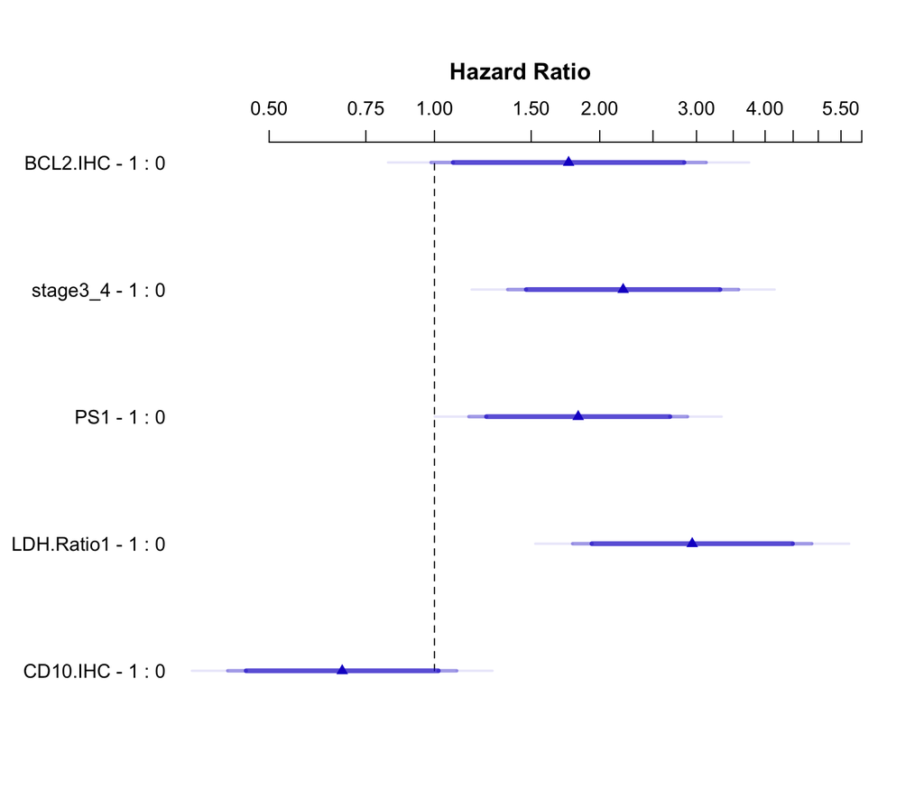

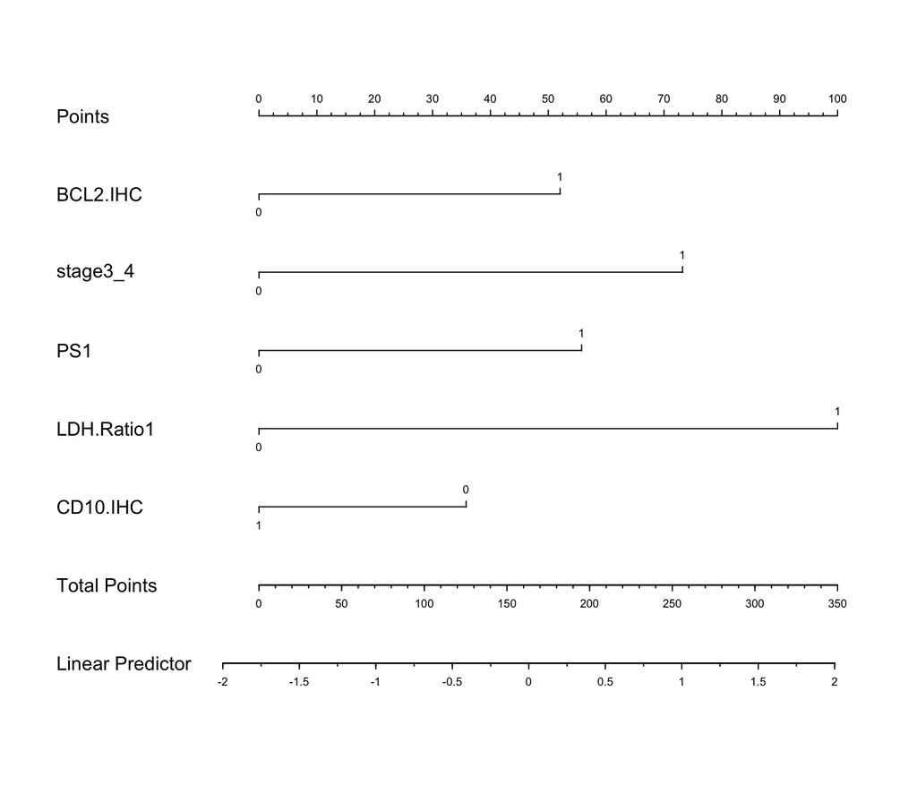

```
##          index.orig     training        test     optimism index.corrected   n
## Dxy     0.518897414  0.524320032 0.503132282  0.021187750      0.49770966 200
## R2      0.279129369  0.289478242 0.265017063  0.024461179      0.25466819 200
## Slope   1.000000000  1.000000000 0.939073456  0.060926544      0.93907346 200
## D       0.078829300  0.083201150 0.074130088  0.009071062      0.06975824 200
## U      -0.002312546 -0.002326009 0.001746196 -0.004072206      0.00175966 200
## Q       0.081141846  0.085527159 0.072383892  0.013143268      0.06799858 200
## g       1.128101204  1.168133015 1.089422635  0.078710380      1.04939082 200
## Cindex  0.759448707  0.762160016 0.751566141  0.010593875      0.74885483 200
```

### 5.4 LASSO2plus prediction

Similarly, we use rms_model to predict LASSO2plus model outcomes.

#### Binary ouctome

```r
p2bfit = rms_model(b2fit$fit, newdata = vdat,
                   outfile = "pred_LASSO2plus_binary")
```

```
##             index.orig     training        test     optimism index.corrected
## Dxy        0.790157068  0.802624223  0.77937173  0.023252496      0.76690457
## R2         0.481472357  0.500029664  0.44187633  0.058153334      0.42331902
## Intercept  0.000000000  0.000000000 -0.15679815  0.156798147     -0.15679815
## Slope      1.000000000  1.000000000  0.81593645  0.184063551      0.81593645
## Emax       0.000000000  0.000000000  0.07409134  0.074091338      0.07409134
## D          0.278185437  0.289578084  0.25229074  0.037287344      0.24089809
## U         -0.009259259 -0.009259259  0.03886982 -0.048129079      0.03886982
## Q          0.287444696  0.298837343  0.21342092  0.085416423      0.20202827
## B          0.064166124  0.061411365  0.06655557 -0.005144210      0.06931033
## g          2.702828922  4.375870272  2.67293996  1.702930314      0.99989861
## gp         0.162611026  0.162718374  0.15738831  0.005330061      0.15728097
## Cindex     0.895078534  0.901312112  0.88968586  0.011626248      0.88345229
##             n
## Dxy       200
## R2        200
## Intercept 200
## Slope     200
## Emax      200
## D         200
## U         200
## Q         200
## B         200
## g         200
## gp        200
## Cindex    200
```

#### Continuous ouctome

For continuous outcomes prediction:

```r
p2cfit = rms_model(c2fit$fit, newdata = vdat,
                   outfile = "pred_LASSO2plus_continuous")
```

```
##           index.orig training     test optimism index.corrected   n
## R-square      0.0652   0.0762   0.0512   0.0251          0.0401 200
## MSE         180.0675 179.0431 182.7673  -3.7243        183.7918 200
## g             3.6221   3.7966   3.4347   0.3619          3.2602 200
## Intercept     0.0000   0.0000   3.1395  -3.1395          3.1395 200
## Slope         1.0000   1.0000   0.9520   0.0480          0.9520 200
```

#### Time-to-event ouctome

To predict time-to-event outcomes:

```r
p2tfit = rms_model(t2fit$fit, data = tdat, newdata = vdat,
                   outfile = "pred_LASSO2plus_time_to_event")
```

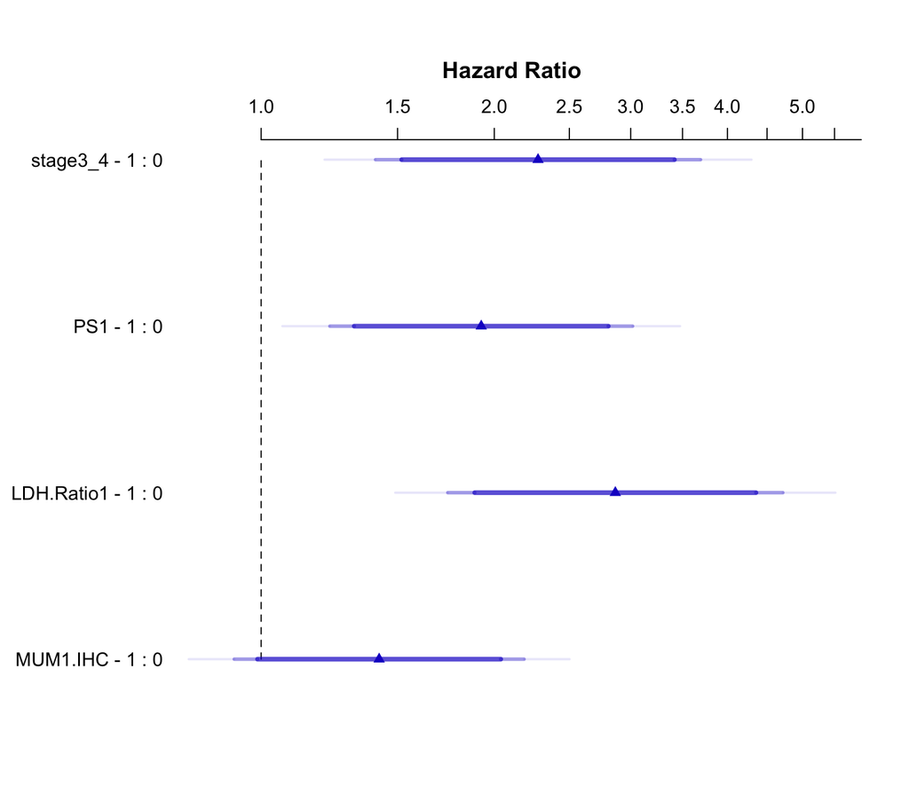

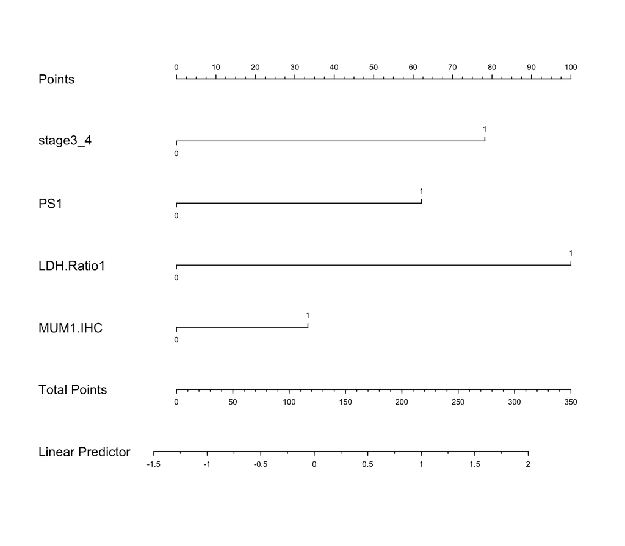

```
##          index.orig     training        test     optimism index.corrected   n
## Dxy     0.513853367  0.517028346 0.500904376  0.016123970     0.497729397 200
## R2      0.265362936  0.276286286 0.254044919  0.022241367     0.243121569 200
## Slope   1.000000000  1.000000000 0.949543664  0.050456336     0.949543664 200
## D       0.074222355  0.078783211 0.070512187  0.008271024     0.065951331 200
## U      -0.002312546 -0.002333007 0.001366078 -0.003699086     0.001386539 200
## Q       0.076534901  0.081116218 0.069146109  0.011970110     0.064564791 200
## g       1.078420120  1.103539420 1.038997673  0.064541746     1.013878374 200
## Cindex  0.756926684  0.758514173 0.750452188  0.008061985     0.748864699 200
```

### 5.5 XGBoost prediction

Continuing, we discuss predictions for the XGBoost model outcomes.

#### Binary ouctome

To predict binary outcomes using the XGBoost model:

```r
pbxfit = XGBtraining_predict(bxfit, newdata = vdat,
                             outfile = "pred_XGBoost_binary")
```

#### Continuous ouctome

For continuous outcomes prediction:

```r
pcxfit = XGBtraining_predict(cxfit, newdata = vdat,
                             outfile = "pred_XGBoost_cont")
```

#### Time-to-event ouctome

To predict time-to-event outcomes:

```r
ptxfit = XGBtraining_predict(txfit, newdata = vdat,
                             outfile = "pred_XGBoost_time_to_event")
```

### 5.6 LASSO2 + XGBoost prediction

Next, we explore predictions for the combined LASSO2 and XGBoost model outcomes.

#### Binary ouctome

To predict binary outcomes:

```r
pblxfit = XGBtraining_predict(blxfit, newdata = vdat,
                              outfile = "pred_LXGBoost_binary")
```

#### Continuous ouctome

To predict continuous outcomes:

```r
pclxfit = XGBtraining_predict(clxfit, newdata = vdat,
                              outfile = "pred_LXGBoost_cont")
```

#### Time-to-event ouctome

To predict time-to-event outcomes:

```r
ptlxfit = XGBtraining_predict(tlxfit, newdata = vdat,
                              outfile = "pred_LXGBoost_time_to_event")
```

#### 5.7 LASSO_plus + XGBoost prediction

Lastly, we discuss predictions for the combined LASSO_plus and XGBoost model outcomes.

##### 1) Binary ouctome

To predict binary outcomes:

```r
pblpxfit = XGBtraining_predict(blpxfit, newdata = vdat,
                               outfile = "pred_LpXGBoost_binary")
```

##### 2) Continuous ouctome

For continuous outcomes prediction:

```r
pclpxfit = XGBtraining_predict(clpxfit, newdata = vdat,
                               outfile = "pred_LpXGBoost_cont")
```

##### 3) Time-to-event ouctome

To predict time-to-event outcomes:

```r
ptlpxfit = XGBtraining_predict(tlpxfit, newdata = vdat,
                               outfile = "pred_LpXGBoost_time_to_event")
```

### 5.8 LASSO2plus + XGBoost prediction

#### Binary ouctome

To predict binary outcomes using the LASSO2plus + XGBoost model:

```r
pbl2xfit = XGBtraining_predict(bl2xfit, newdata = vdat,
                               outfile = "pred_L2XGBoost_binary")
```

#### Continuous ouctome

For continuous outcomes prediction:

```r
pcl2xfit = XGBtraining_predict(cl2xfit, newdata = vdat,
                               outfile = "pred_L2XGBoost_cont")
```

#### Time-to-event ouctome

To predict time-to-event outcomes:

```r
ptl2xfit = XGBtraining_predict(tl2xfit, newdata = vdat,
                               outfile = "pred_L2XGBoost_time_to_event")
```

## 6. (External) Model Validation

In the validation phase, we assess our models’ effectiveness by utilizing a fresh dataset that includes the outcome variable. This separate dataset, known as the validation dataset, stands distinct from the one used for training and is termed external validation. This distinction is crucial, setting it apart from internal validation methods such as sampling, cross-validation, leave-one-out, and bootstrapping.

It’s important to emphasize that while the same functions are used for both prediction and validation, the validation process requires the inclusion of an outcome variable. This distinction prompts additional analyses and comparisons beyond mere prediction.

All generated validation plots and associated result files are stored locally for easy reference.

### 6.1 LASSO2 validation

We conduct validation for the LASSO2 model with different types of outcome variables.

#### Binary ouctome

```r
vbl = LASSO2_predict(bl, newdata = vdat, newY = TRUE,
                     outfile = "valid_LASSO2_binary")
```

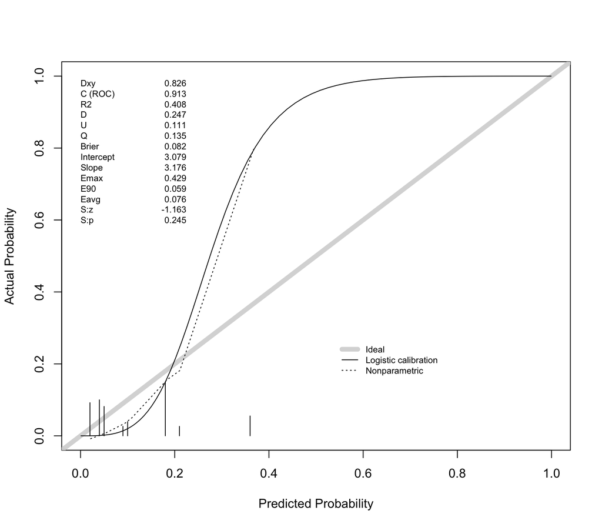

While the returned object vbl also holds predicted probabilities for the ’DZsig’ positive group, in addition, a validation performance figure is saved locally.

#### Continuous ouctome

```r
vcl = LASSO2_predict(cl, newdata = vdat, newY = TRUE,
                     outfile = "valid_LASSO2_cont")
```

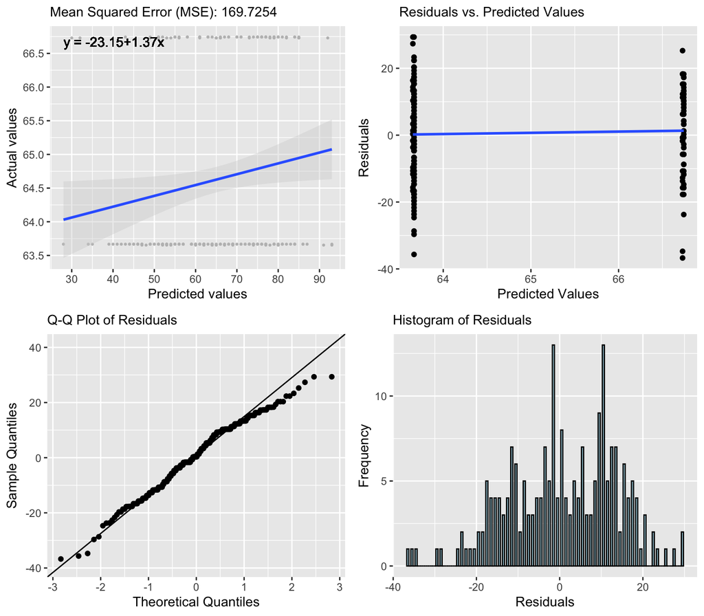

Similarly, the returned object vcl holds predicted value, and a validation performance plot is saved.

#### Time-to-event ouctome

```r
vtl = LASSO2_predict(tl, newdata = vdat, newY = TRUE,
               outfile = "valid_LASSO2_time_to_event")
```

The returned object vtl keeps the predicted risk scores, and locally saved validation results include a calibration plot and a table containing performance statistics.

### 6.2 LASSO2 + regular regression validation

Similar to prediction step, we use rms_model to validate the regular regression model using the selected variables from LASSO2.

#### Binary ouctome

```r
vblr = rms_model(blr$fit, newdata = vdat, newY = TRUE,
                 outfile = "valid_LASSO2reg_binary")
```

```
##             index.orig     training        test     optimism index.corrected
## Dxy        0.790157068  0.805280242  0.77889424  0.026386001      0.76377107
## R2         0.481472357  0.502776232  0.44027291  0.062503318      0.41896904
## Intercept  0.000000000  0.000000000 -0.20203875  0.202038748     -0.20203875
## Slope      1.000000000  1.000000000  0.79504430  0.204955699      0.79504430
## Emax       0.000000000  0.000000000  0.08915997  0.089159965      0.08915997
## D          0.278185437  0.291704020  0.25134484  0.040359181      0.23782626
## U         -0.009259259 -0.009259259  0.03247846 -0.041737718      0.03247846
## Q          0.287444696  0.300963280  0.21886638  0.082096898      0.20534780
## B          0.064166124  0.061293619  0.06638596 -0.005092340      0.06925846
## g          2.702828922  4.336628335  2.67673621  1.659892126      1.04293680
## gp         0.162611026  0.163300938  0.15679983  0.006501113      0.15610991
## Cindex     0.895078534  0.902640121  0.88944712  0.013193000      0.88188553
##             n
## Dxy       200
## R2        200
## Intercept 200
## Slope     200
## Emax      200
## D         200
## U         200
## Q         200
## B         200
## g         200
## gp        200
## Cindex    200
```

The above code generates and saves two figures and five tables and some of them are duplicated to the prediction step.

#### Continuous ouctome

```r
vclr = rms_model(clr$fit, newdata = vdat, newY = TRUE,
                 outfile = "valid_LASSO2reg_continuous")
```

```
##           index.orig training     test optimism index.corrected   n
## R-square      0.0652   0.0749   0.0520   0.0229          0.0422 200
## MSE         180.0675 179.5373 182.6117  -3.0745        183.1420 200
## g             3.6221   3.7422   3.4538   0.2883          3.3338 200
## Intercept     0.0000   0.0000   1.1669  -1.1669          1.1669 200
## Slope         1.0000   1.0000   0.9813   0.0187          0.9813 200
```

The above code also generates and saves two figures and five tables and some of them are duplicated to the prediction step.

#### Time-to-event ouctome

```r
vtlr = rms_model(tlr$fit, data = tdat, newdata = vdat, newY = TRUE,
                 outfile = "valid_LASSO2reg_time_to_event")
```

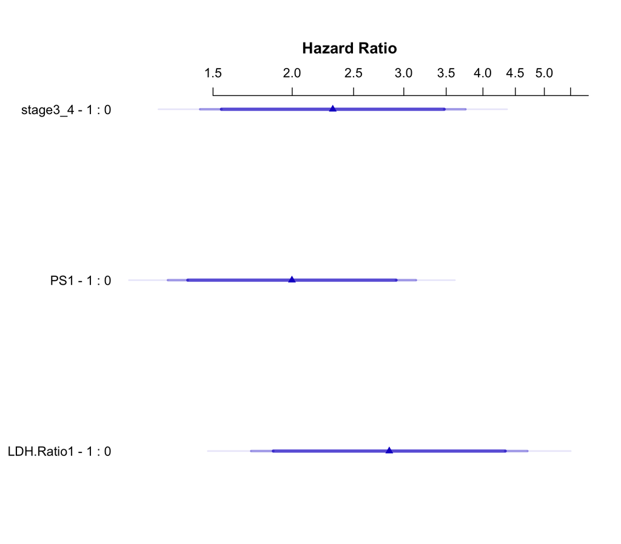

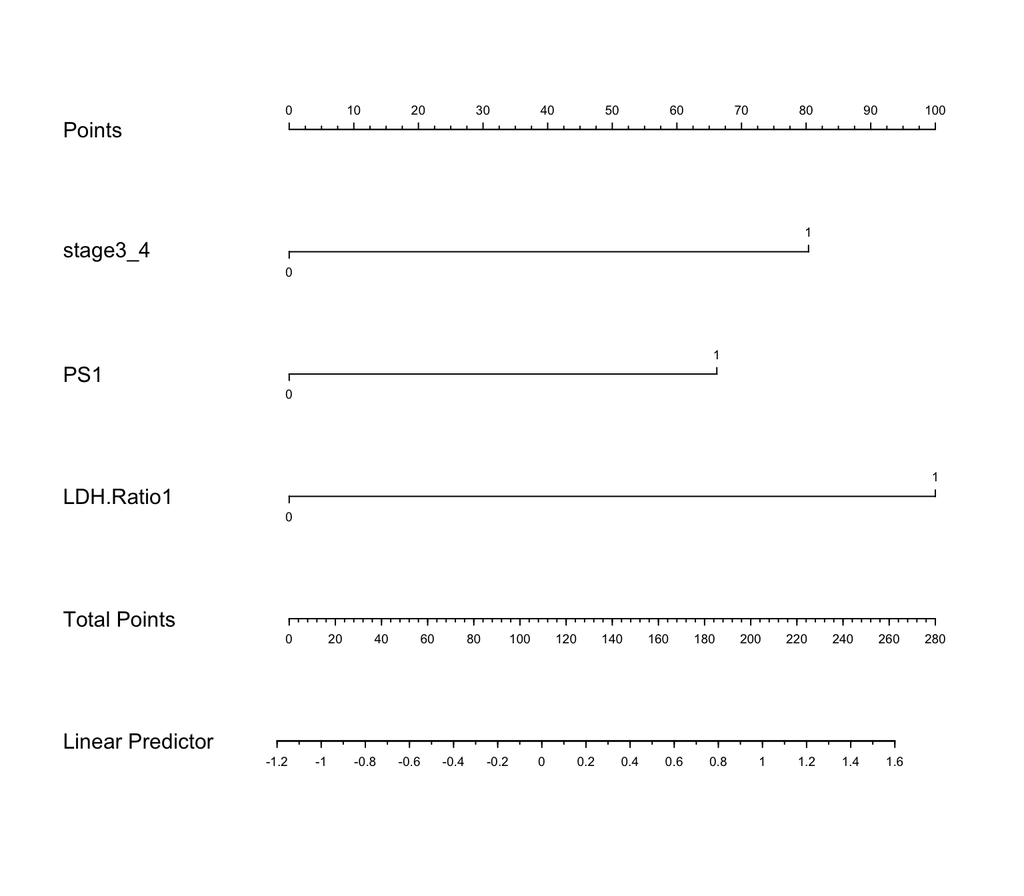

```
##          index.orig    training        test     optimism index.corrected   n
## Dxy     0.497655584  0.50187266 0.487219381  0.014653279     0.483002305 200
## R2      0.256358679  0.26894320 0.249267042  0.019676158     0.236682521 200
## Slope   1.000000000  1.00000000 0.962113454  0.037886546     0.962113454 200
## D       0.071254401  0.07556182 0.068952046  0.006609776     0.064644625 200
## U      -0.002312546 -0.00230685 0.001172984 -0.003479834     0.001167288 200
## Q       0.073566947  0.07786867 0.067779062  0.010089610     0.063477336 200
## g       1.041611086  1.07390634 1.020356936  0.053549403     0.988061683 200
## Cindex  0.748827792  0.75093633 0.743609690  0.007326639     0.741501152 200
```

Same as for prediction step, validation of time-to-event outcome requires training data as well. The above code generates and saves two figures and six tables and some of them are duplicated to the prediction step.

### 6.3 LASSO_plus validation

Next, we utilize the same rms_model function for validating the LASSO_plus models, with parameter settings and outputs mirroring those detailed in the model validation of Section 6.2.

#### Binary ouctome

```r
vbfit = rms_model(bfit$fit, newdata = vdat, newY = TRUE,
                  outfile = "valid_LASSOplus_binary")
```

```
##             index.orig     training        test     optimism index.corrected
## Dxy        0.790157068  0.802871836  0.77875812  0.024113721      0.76604335
## R2         0.481472357  0.498036928  0.43895447  0.059082463      0.42238989
## Intercept  0.000000000  0.000000000 -0.22380430  0.223804295     -0.22380430
## Slope      1.000000000  1.000000000  0.80972695  0.190273054      0.80972695
## Emax       0.000000000  0.000000000  0.08983063  0.089830626      0.08983063
## D          0.278185437  0.289095562  0.25044355  0.038652014      0.23953342
## U         -0.009259259 -0.009259259  0.03944186 -0.048701121      0.03944186
## Q          0.287444696  0.298354821  0.21100169  0.087353135      0.20009156
## B          0.064166124  0.062756840  0.06662721 -0.003870371      0.06803649
## g          2.702828922  4.386345417  2.67357477  1.712770651      0.99005827
## gp         0.162611026  0.163951017  0.15687994  0.007071081      0.15553994
## Cindex     0.895078534  0.901435918  0.88937906  0.012056860      0.88302167
##             n
## Dxy       200
## R2        200
## Intercept 200
## Slope     200
## Emax      200
## D         200
## U         200
## Q         200
## B         200
## g         200
## gp        200
## Cindex    200
```

#### Continuous ouctome

```r
vcfit = rms_model(cfit$fit, newdata = vdat, newY = TRUE,
                  outfile = "valid_LASSOplus_continuous")
```

```
##           index.orig training     test optimism index.corrected   n
## R-square      0.0652   0.0739   0.0512   0.0227          0.0425 200
## MSE         180.0675 176.6717 182.7615  -6.0898        186.1573 200
## g             3.6221   3.6842   3.4204   0.2638          3.3583 200
## Intercept     0.0000   0.0000   0.8450  -0.8450          0.8450 200
## Slope         1.0000   1.0000   0.9846   0.0154          0.9846 200
```

#### Time-to-event ouctome

```r
vtfit = rms_model(tfit$fit, data = tdat, newdata = vdat, newY = TRUE,
                  outfile = "valid_LASSOplus_time_to_event")
```

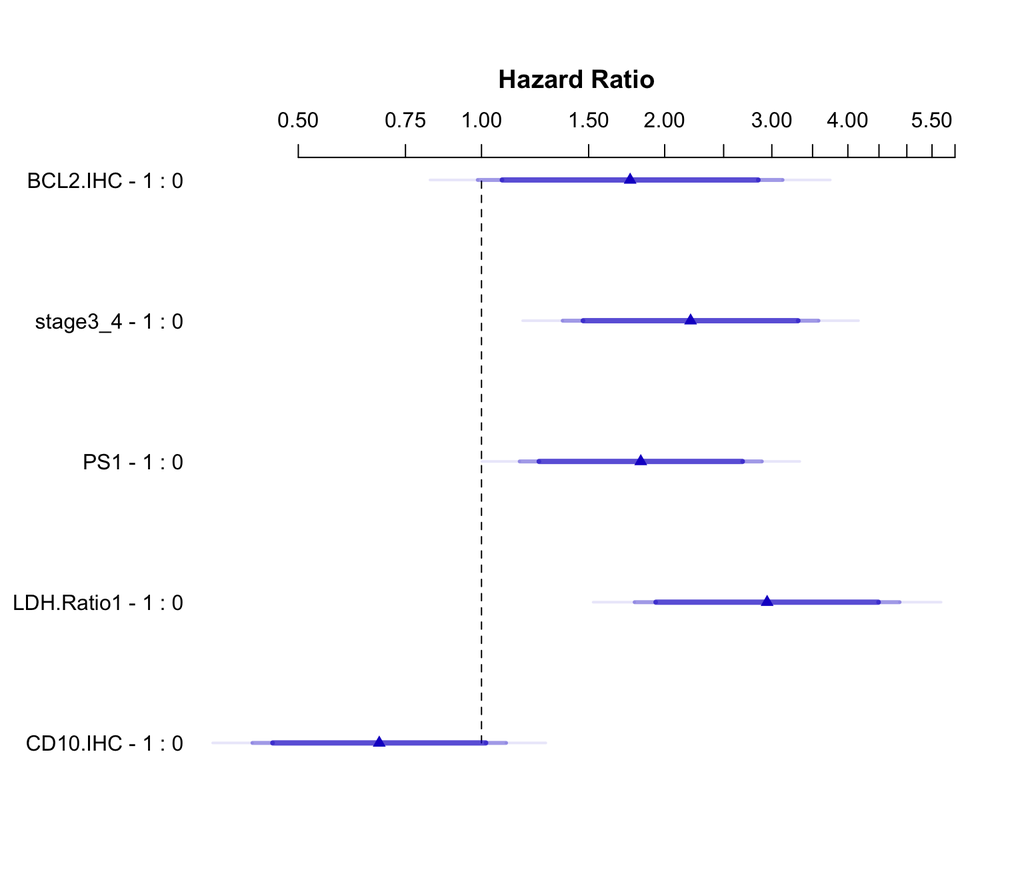

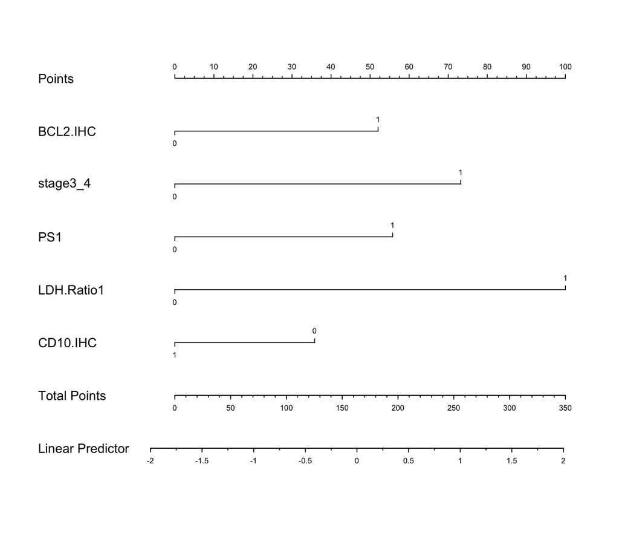

```
##          index.orig     training       test     optimism index.corrected   n
## Dxy     0.518897414  0.528332595 0.50403097  0.024301621     0.494595793 200
## R2      0.279129369  0.294747489 0.26514249  0.029604998     0.249524371 200
## Slope   1.000000000  1.000000000 0.93341733  0.066582674     0.933417326 200
## D       0.078829300  0.084927191 0.07417035  0.010756839     0.068072461 200
## U      -0.002312546 -0.002328557 0.00192846 -0.004257017     0.001944471 200
## Q       0.081141846  0.087255748 0.07224189  0.015013856     0.066127990 200
## g       1.128101204  1.183761294 1.08935280  0.094408494     1.033692710 200
## Cindex  0.759448707  0.764166298 0.75201549  0.012150810     0.747297897 200
```

### 6.4 LASSO2plus validation

#### Binary ouctome

```r
v2bfit = rms_model(b2fit$fit, newdata = vdat, newY = TRUE,
                   outfile = "valid_LASSO2plus_binary")
```

```
##             index.orig     training        test     optimism index.corrected
## Dxy        0.790157068  0.806889501  0.77824712  0.028642381      0.76151469
## R2         0.481472357  0.508135670  0.43766621  0.070469459      0.41100290
## Intercept  0.000000000  0.000000000 -0.24055574  0.240555736     -0.24055574
## Slope      1.000000000  1.000000000  0.78694925  0.213050750      0.78694925
## Emax       0.000000000  0.000000000  0.09963512  0.099635120      0.09963512
## D          0.278185437  0.297637688  0.24963425  0.048003435      0.23018200
## U         -0.009259259 -0.009259259  0.03691791 -0.046177174      0.03691791
## Q          0.287444696  0.306896948  0.21271634  0.094180609      0.19326409
## B          0.064166124  0.061387091  0.06647851 -0.005091420      0.06925754
## g          2.702828922  4.444460447  2.67871852  1.765741925      0.93708700
## gp         0.162611026  0.166089080  0.15657987  0.009509214      0.15310181
## Cindex     0.895078534  0.903444751  0.88912356  0.014321190      0.88075734
##             n
## Dxy       200
## R2        200
## Intercept 200
## Slope     200
## Emax      200
## D         200
## U         200
## Q         200
## B         200
## g         200
## gp        200
## Cindex    200
```

#### Continuous ouctome

```r
v2cfit = rms_model(c2fit$fit, newdata = vdat, newY = TRUE,
                   outfile = "valid_LASSO2plus_continuous")
```

```
##           index.orig training     test optimism index.corrected   n
## R-square      0.0652   0.0739   0.0520   0.0219          0.0433 200
## MSE         180.0675 177.1813 182.5975  -5.4162        185.4837 200
## g             3.6221   3.7075   3.4447   0.2627          3.3594 200
## Intercept     0.0000   0.0000   1.3316  -1.3316          1.3316 200
## Slope         1.0000   1.0000   0.9801   0.0199          0.9801 200
```

#### Time-to-event ouctome

```r
v2tfit = rms_model(t2fit$fit, data = tdat, newdata = vdat, newY = TRUE,
                   outfile = "valid_LASSO2plus_time_to_event")
```

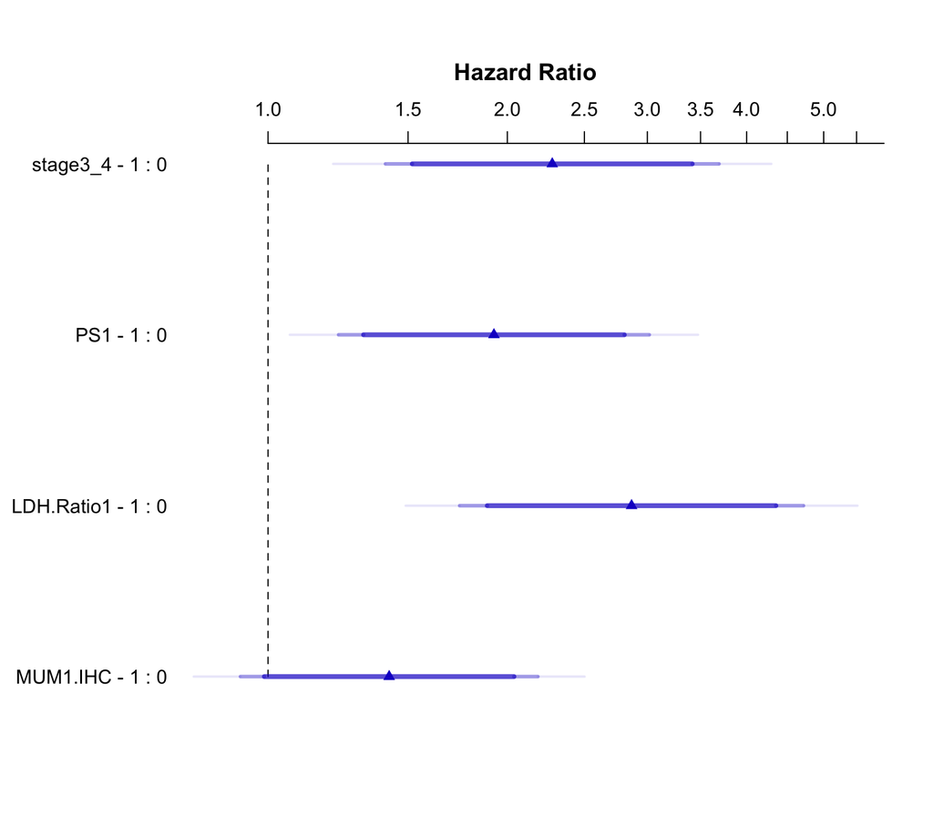

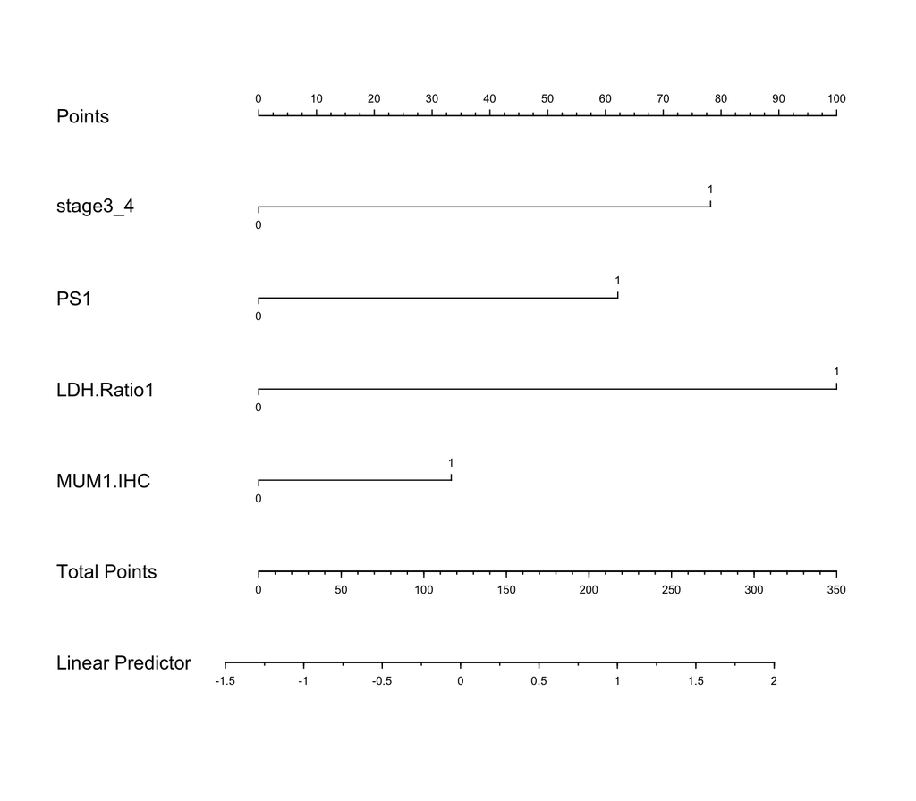

```
##          index.orig     training        test     optimism index.corrected   n
## Dxy     0.513853367  0.521733799 0.499087099  0.022646701     0.491206667 200
## R2      0.265362936  0.280803488 0.253591881  0.027211607     0.238151330 200
## Slope   1.000000000  1.000000000 0.933706864  0.066293136     0.933706864 200
## D       0.074222355  0.080612184 0.070368768  0.010243416     0.063978939 200
## U      -0.002312546 -0.002341967 0.001647714 -0.003989681     0.001677135 200
## Q       0.076534901  0.082954151 0.068721054  0.014233097     0.062301804 200
## g       1.078420120  1.122486802 1.040338639  0.082148163     0.996271957 200
## Cindex  0.756926684  0.760866900 0.749543549  0.011323350     0.745603333 200
```

### 6.5 XGBoost validation

The XGBtraining_predict function introduced in Section 5.5, also serves for model validation when the outcome variable is present in the validation cohort. The parameter settings and outputs are the same as those for the LASSO2_prediction function detailed in Section 6.1.

#### Binary ouctome

```r
vbxfit = XGBtraining_predict(bxfit, newdata = vdat, newY = TRUE,
                             outfile = "valid_XGBoost_binary")
```

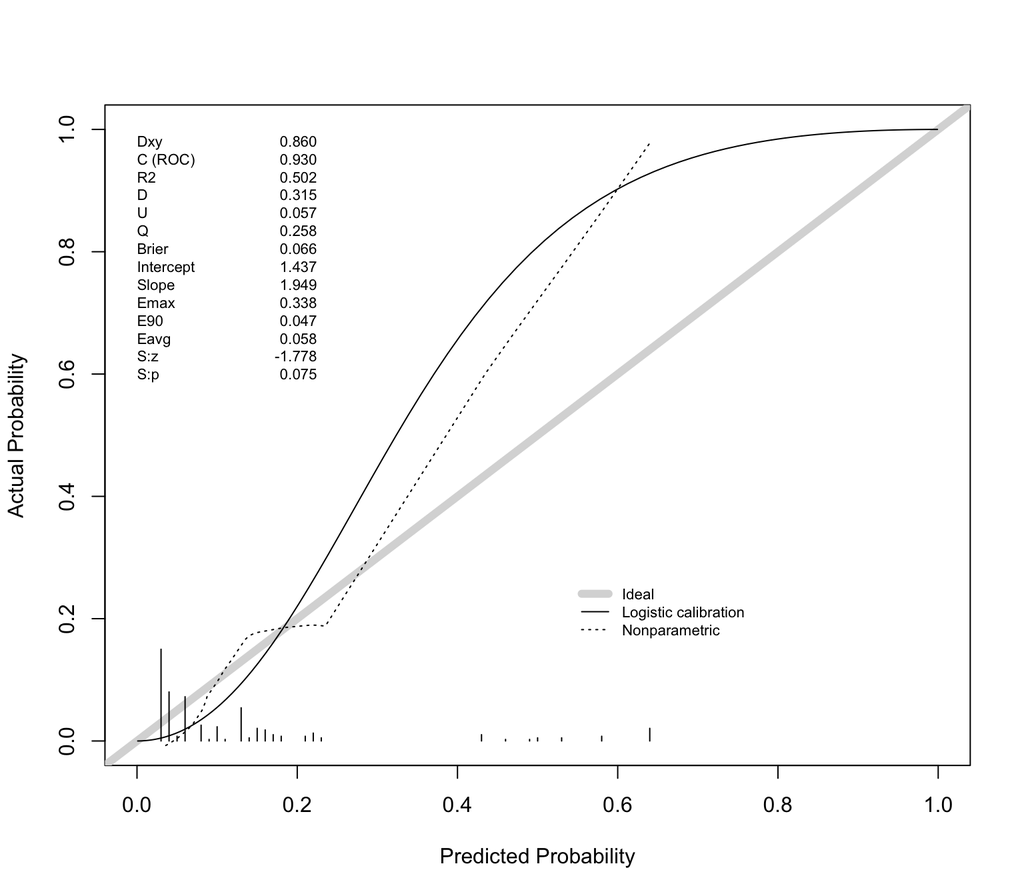

Predicted probability for the positive group is given for each entry/sample.

#### Continuous ouctome

```r
vcxfit = XGBtraining_predict(cxfit, newdata = vdat, newY = TRUE,
                             outfile = "valid_XGBoost_cont")
```

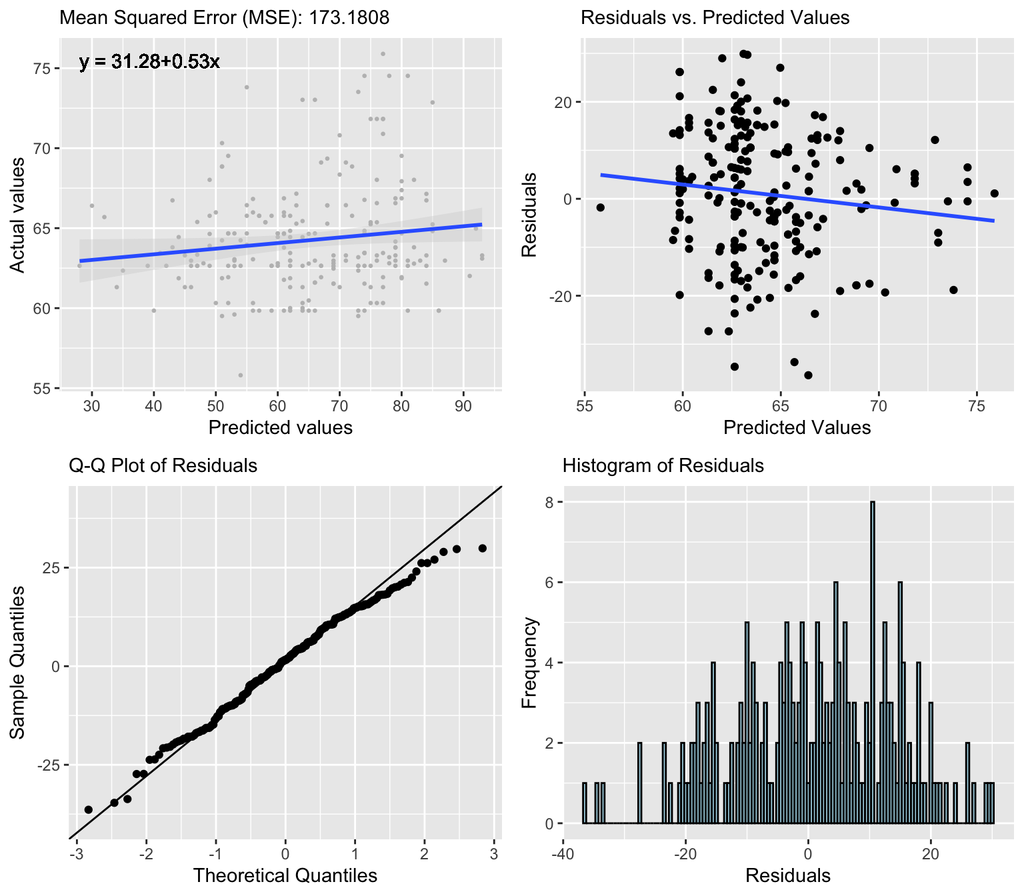

#### Time-to-event ouctome

```r
vtxfit = XGBtraining_predict(txfit, newdata = vdat, newY = TRUE,
                             outfile = "valid_XGBoost_time_to_event")
```

### 6.6 LASSO2 + XGBoost validation

The same XGBtraining_predict function is employed for LASSO2 + XGBoost model validation as for the standalone XGBoost model shown in Section 6.5, with consistent parameter settings and identical outputs.

#### Binary ouctome

```r
vblxfit = XGBtraining_predict(blxfit, newdata = vdat, newY = TRUE,
                              outfile = "valid_LXGBoost_binary")
```

#### Continuous ouctome

```r
vclxfit = XGBtraining_predict(clxfit, newdata = vdat, newY = TRUE,
                              outfile = "valid_LXGBoost_cont")
```

#### Time-to-event ouctome

```r
vtlxfit = XGBtraining_predict(tlxfit, newdata = vdat, newY = TRUE,
                              outfile = "valid_LXGBoost_time_to_event")
```

### 6.7 LASSO_plus + XGBoost validation

The same XGBtraining_predict function is employed for LASSO_plus + XGBoost model validation as for the standalone XGBoost model shown in Section 6.5, with consistent parameter settings and identical outputs.

#### Binary ouctome

```r
vblpxfit = XGBtraining_predict(blpxfit, newdata = vdat, newY = TRUE,
                               outfile = "valid_LpXGBoost_binary")
```

#### Continuous ouctome

```r
vclpxfit = XGBtraining_predict(clpxfit, newdata = vdat, newY = TRUE,
                               outfile = "valid_LpXGBoost_cont")
```

#### Time-to-event ouctome

```r
vtlpxfit = XGBtraining_predict(tlpxfit, newdata = vdat, newY = TRUE,
                               outfile = "valid_LpXGBoost_time_to_event")
```

### 6.8 LASSO2plus + XGBoost validation

The same XGBtraining_predict function is employed for LASSO2plus + XGBoost model validation as for the standalone XGBoost model shown in Section 6.5, with consistent parameter settings and identical outputs.

#### Binary ouctome

```r
vbl2xfit = XGBtraining_predict(bl2xfit, newdata = vdat, newY = TRUE,
                               outfile = "valid_L2XGBoost_binary")
```

#### Continuous ouctome

```r
vcl2xfit = XGBtraining_predict(cl2xfit, newdata = vdat, newY = TRUE,
                               outfile = "valid_L2XGBoost_cont")
```

#### Time-to-event ouctome

```r
vtl2xfit = XGBtraining_predict(tl2xfit, newdata = vdat, newY = TRUE,
                               outfile = "valid_L2XGBoost_time_to_event")
```

## 7. All-in-one!

If you find it challenging to call various functions separately, the all-in-one function provides a simplified solution. It efficiently manages predictive model development and validation for all eight methods integrated into this package, spanning three distinct outcome types, with a single function call. Moreover, you can employ this versatile function for a single method with one or more outcome variables, offering flexibility to suit your specific needs. If a validation dataset is at your disposal, the function seamlessly incorporates the validation process within the same operation.

```r
modelout = csmpvModelling(tdat = tdat, vdat = vdat,
                          Ybinary = "DZsig", varsBinary = DZXvars,
                          Ycont = "Age", varsCont = AgeXvars,
                          time = "FFP..Years.", event = "Code.FFP",
                          varsSurvival = Xvars,
                          outfileName= "all_in_one")
```

This single function call generates all models and provides predictions and validations for each of them with our example training data: tdat and validation data: vdat.. To save space, the running results are hidden. In other words, this single function call can replace all three sections discussed in Sections 4, 5, and 6. The models will be returned, and all result files will be saved locally.

Certainly, we can use this all-in-one function to work on one outcome variable and one model at a time, for example:

```r
DZlassoreg = csmpvModelling(tdat = tdat, vdat = vdat,
                            Ybinary = "DZsig", varsBinary = DZXvars,
                            methods = "LASSO2_reg",
                            outfileName= "just_one")
```

```
## Resized limits to included dashed line in forest panel
## Resized limits to included dashed line in forest panel
## Resized limits to included dashed line in forest panel
```

[output not shown]

```
##             index.orig     training        test     optimism index.corrected
## Dxy        0.790157068  0.808677952  0.77920628  0.029471669      0.76068540
## R2         0.481472357  0.512699837  0.44932805  0.063371790      0.41810057
## Intercept  0.000000000  0.000000000 -0.17317116  0.173171162     -0.17317116
## Slope      1.000000000  1.000000000  0.81893542  0.181064577      0.81893542
## Emax       0.000000000  0.000000000  0.07665136  0.076651362      0.07665136
## D          0.278185437  0.302088609  0.25707195  0.045016659      0.23316878
## U         -0.009259259 -0.009259259  0.03268729 -0.041946552      0.03268729
## Q          0.287444696  0.311347868  0.22438466  0.086963211      0.20048149
## B          0.064166124  0.060690653  0.06634248 -0.005651823      0.06981795
## g          2.702828922  4.163927151  2.67611561  1.487811540      1.21501738
## gp         0.162611026  0.167434696  0.15867911  0.008755583      0.15385544
## Cindex     0.895078534  0.904338976  0.88960314  0.014735835      0.88034270
##             n
## Dxy       200
## R2        200
## Intercept 200
## Slope     200
## Emax      200
## D         200
## U         200
## Q         200
## B         200
## g         200
## gp        200
## Cindex    200
```

This is equivalent to using LASSO2_reg for modeling, followed by prediction and validation with rms_model for the “DZsig” classification.

## 8. Special modelling

In preceding sections, the target model type consistently matched the provided output. However, scenarios can emerge where they do not necessarily correspond.

For instance, situations might arise in which we aim to construct a risk classification model even when our training cohort lacks risk classification data but includes survival information.

To undertake this specialized modeling, let’s assume that we have a set of variables associated with survival outcomes. XGpred can utilize all of these variables and provides choices for variable selection within the functions with three options: LASSO2, LASSO2plus, and LASSO_plus.

By employing the same variable list, denoted as Xvars, we can invoke the XGpred function with options to perform variable selection using LASSO_plus to identify the top 5 variables. This wrapper function applies XGBoost and Cox modeling to determine high and low-risk groups using survival data. Subsequently, these groups undergo filtration and are used to construct an empirical Bayesian-based binary risk classification model.

```r
xgobj = XGpred(data = tdat, varsIn = Xvars,
               selection = TRUE,
               vsMethod = "LASSO_plus",
               topN = 5,
               time = "FFP..Years.",
               event = "Code.FFP",
               outfile = "XGpred")
```

The XGpred output object, xgobj, encompasses all the essential information for risk classification, including that of the training cohort.

By default, this function generates binary classification; any samples not classified into high-risk groups are placed into the low-risk group. When ‘nclass’ is set to 3, samples are categorized into low, middle, and high-risk groups, as demonstrated with the following code:

```r
xgobj3 = XGpred(data = tdat, varsIn = Xvars,
               time = "FFP..Years.",
               event = "Code.FFP",
               selection = TRUE,
               vsMethod = "LASSO_plus",
               topN = 5,
               nclass = 3,
               outfile = "XGpred")
```

To observe the performance of the risk group in the training set, we can generate a KM plot using the confirmVars function:

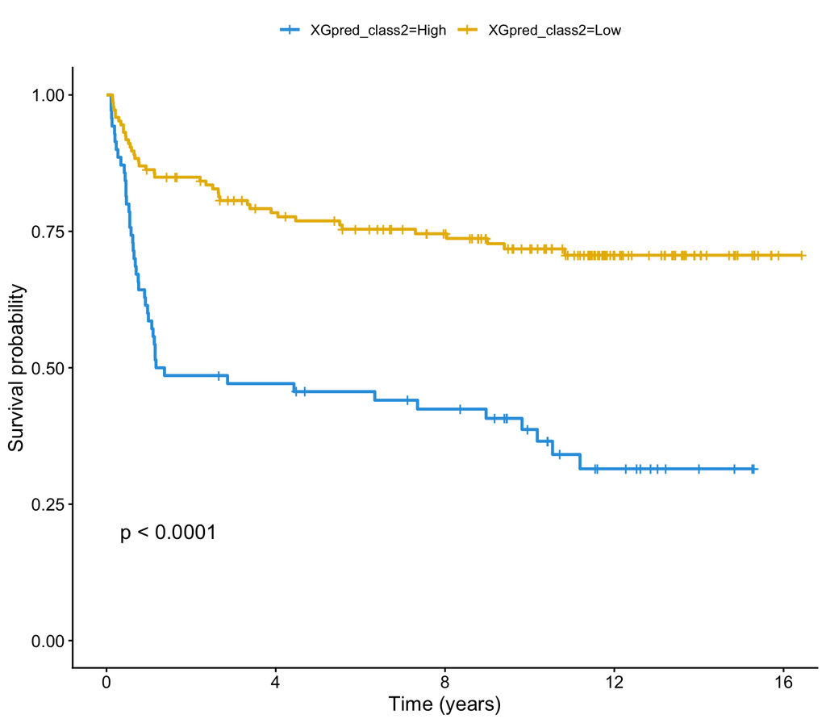

```r
tdat$XGpred_class2 = xgobj$XGpred_prob_class
training_risk_confirm2 = confirmVars(data = tdat, biomks = "XGpred_class2",
                                    time = "FFP..Years.", event = "Code.FFP",
                                    outfile = "training2grps_riskSurvival",
                                    outcomeType = "time-to-event")
training_risk_confirm2[[3]]
```

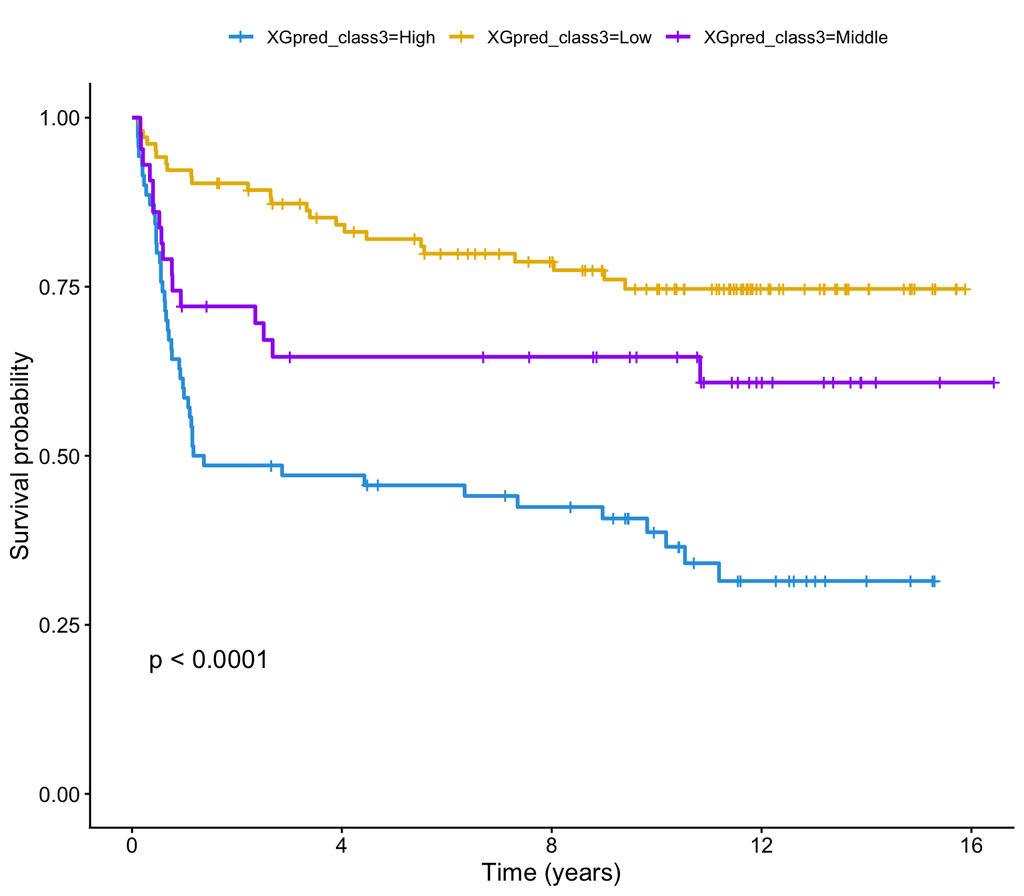

```r
tdat$XGpred_class3 = xgobj3$XGpred_prob_class
training_risk_confirm3 = confirmVars(data = tdat, biomks = "XGpred_class3",
                                    time = "FFP..Years.", event = "Code.FFP",
                                    outfile = "training3grps_riskSurvival",
                                    outcomeType = "time-to-event")
training_risk_confirm3[[3]]
```

Then we can predict the risk classification for a validation cohort:

```r
xgNew = XGpred_predict(newdat = vdat, XGpredObj = xgobj)
xgNew3 = XGpred_predict(newdat = vdat, XGpredObj = xgobj3)
```

While the default calibration shift (scoreShift) is set to 0, you can adjust it based on model scores if there’s a platform/batch difference between the training and validation cohorts.

If survival data is available for the testing dataset, we can employ the confirmVars function introduced earlier to assess the reasonableness of risk classification.

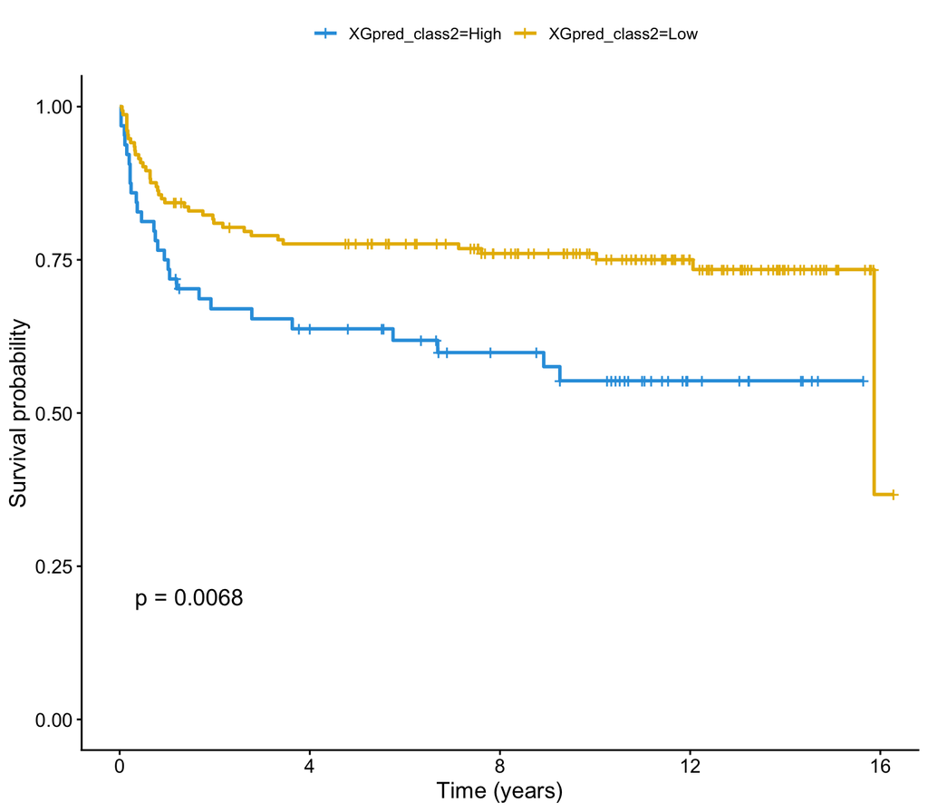

```r
vdat$XGpred_class2 = xgNew$XGpred_prob_class
risk_confirm2 = confirmVars(data = vdat, biomks = "XGpred_class2",
                           time = "FFP..Years.", event = "Code.FFP",
                           outfile = "riskSurvival2grps",
                           outcomeType = "time-to-event")
risk_confirm2[[3]]
```

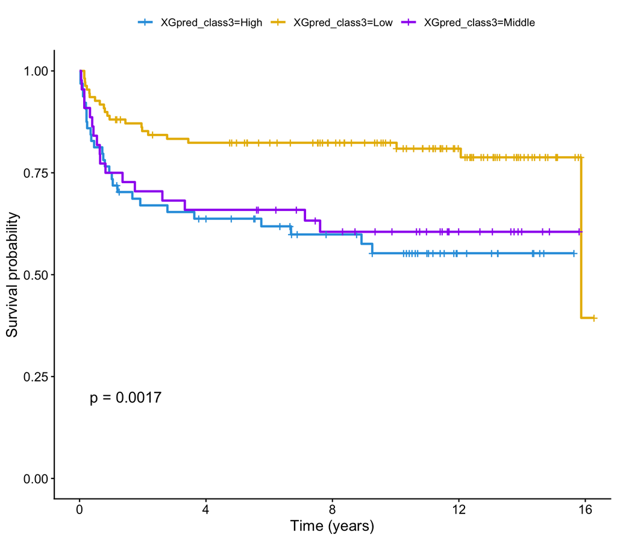

```r
vdat$XGpred_class3 = xgNew3$XGpred_prob_class
risk_confirm3 = confirmVars(data = vdat, biomks = "XGpred_class3",
                           time = "FFP..Years.", event = "Code.FFP",
                           outfile = "riskSurvival3grps",
                           outcomeType = "time-to-event")
risk_confirm3[[3]]
```

## csmpv R package general information

Title: Biomarker confirmation, selection, modelling, prediction and validation

Version: 1.0.2

Author: Aixiang Jiang

Maintainer: Aixiang Jiang aijiang@bccrc.ca{.email}

Depends: R (>= 4.2.0)

Suggests: knitr

VignetteBuilder: knitr

Imports: survival, glmnet, Hmisc, rms, forestmodel, ggplot2, ggpubr,survminer, mclust, xgboost, cowplot

## References

Hastie et al. (1992, ISBN 0 534 16765-9)

Therneau et al. (2000, ISBN 0-387-98784-3)

Friedman et al. (2010) doi:10.18637/jss.v033.i01

Simon et al. (2011) doi:doi:10.18637/jss.v039.i05

Chen and Guestrin (2016) <arXiv:1603.02754>

Aoki et al. (2023) doi:10.1200/JCO.23.01115